# Les réseaux sociaux et la transition à l’âge adulte au Québec - 2025-07-18

#### Affichage

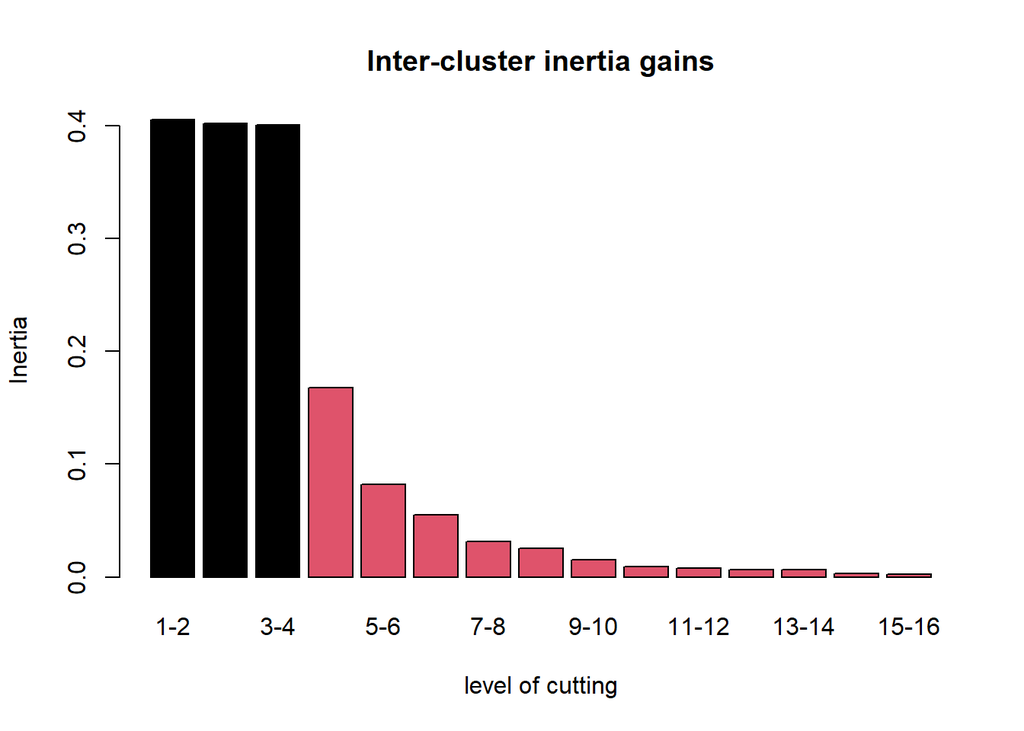

```r
plot(cah, choice = "bar")
```

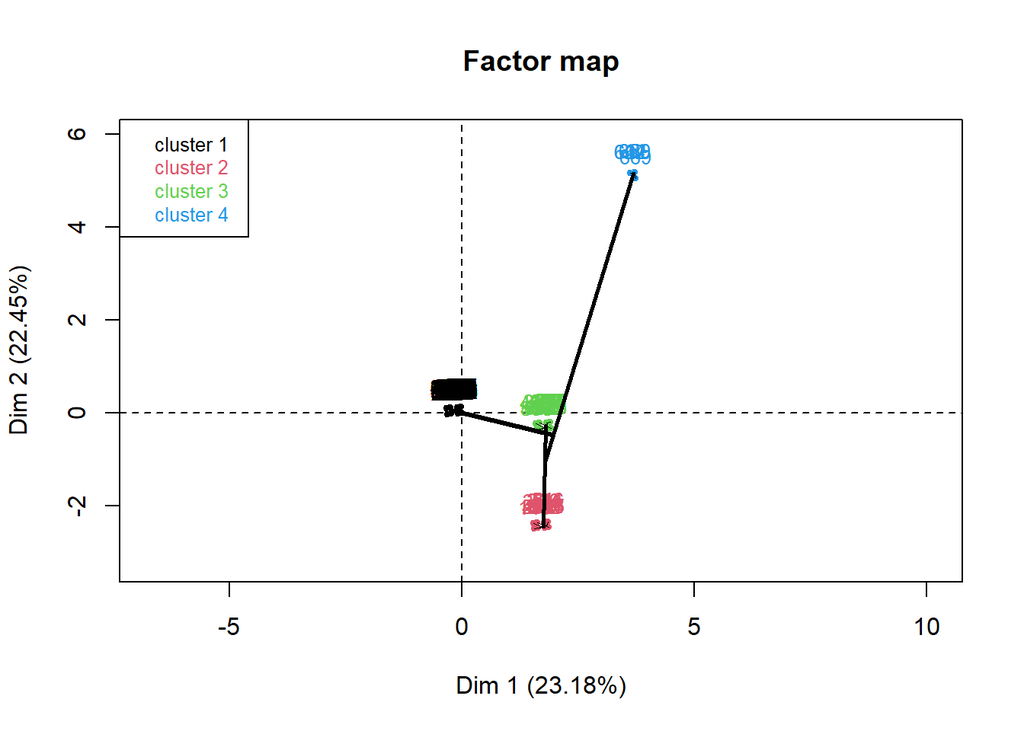

```r
plot(cah, choice = "map")
```

```r
#cah$data.clust
```

# Observations simultanées des marqueurs objectifs et subjectifs

## Graphique pour les Marqueurs objectifs et subjectifs

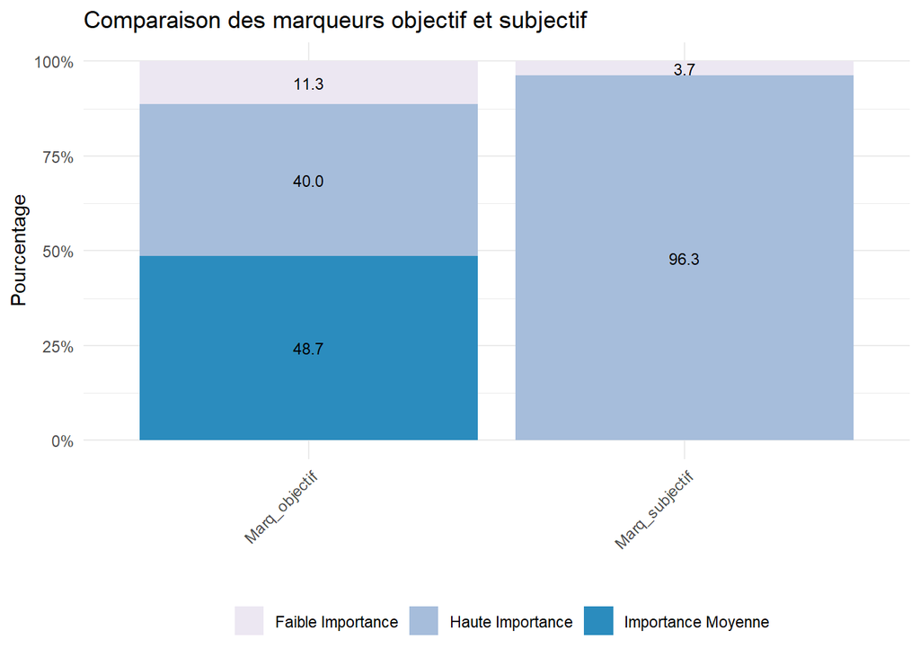

```r
# Préparation des données au format long
data_long <- data_design$variables %>%
  select(Marq_objectif, Marq_subjectif) %>%
  pivot_longer(cols = everything(), names_to = "Marqueur", values_to = "Importance") %>%
  group_by(Marqueur, Importance) %>%
  summarise(Count = n(), .groups = 'drop') %>%
  group_by(Marqueur) %>%
  mutate(Percentage = Count / sum(Count) * 100) %>%
  ungroup()

# Création du graphique à barres empilées
graphique <- ggplot(data_long, aes(x = Marqueur, y = Percentage, fill = as.factor(Importance))) +
  geom_bar(stat = "identity") +
  geom_text(aes(label = sprintf("%.1f", Percentage)),
            position = position_stack(vjust = 0.5), size = 3) +
  labs(x = "", y = "Pourcentage", fill = "",
       title = "Comparaison des marqueurs objectif et subjectif") +
  scale_y_continuous(labels = percent_format(scale = 1)) +
  scale_fill_brewer(palette = "PuBu") +
  theme_minimal() +
  theme(legend.position = "bottom",
        axis.text.x = element_text(angle = 45, hjust = 1))

# Sauvegarde du graphique
ggsave(here("figures", "marqueur_Objectif_subjectif", "Somme_subjectif_objecti_echantillon_plot.png"),
       plot = graphique, width = 10, height = 6)


# Affichage du graphique
graphique
```

## Classification pour les deux marqueurs et choix du meilleur k

```r
library(dplyr)
library(dendextend)
library(ade4)
library(ggdendro)
library(fastcluster)
#library(devtools)
#install_github("larmarange/JLutils")
#library(JLutils)
#source(url("https://raw.githubusercontent.com/larmarange/JLutils/master/R/clustering.R"))

data_interest<-0
data_interest <- data_design$variables %>%
  select(Somme_Importance,Somme_Importance_subjectif,gpe_age) %>%
  na.omit()

# Convertir les variables en facteurs
data_interest <- data_interest %>%
  mutate(across(everything(), as.factor))



# Supprimer les niveaux de facteurs sans occurrences
data_interest <- data_interest %>%
  mutate(across(everything(), ~ fct_drop(.)))

# Suppression des niveaux inutilisés de la variable Somme_Importance_subjectif
data_interest$Somme_Importance_subjectif <- fct_drop(data_interest$Somme_Importance_subjectif)

# Vérifier la distribution des catégories pour chaque variable
summary(data_interest)
```

```
##                      Somme_Importance                Somme_Importance_subjectif
##  0 oui (rien n’est important): 28     0 oui (rien n’est important):  6
##  1 oui                       : 54     1 oui                       : 21
##  2 oui                       :197     2 oui                       : 37
##  3 oui                       :155     3 oui (tout est important)  :659
##  4 oui                       :142
##  5 oui (tout est important)  :147
##       gpe_age
##  18-24 ans:340
##  25-34 ans:383
##
##
##
##
```

```r
acm <- dudi.acm(data_interest, scannf = FALSE, nf = 5)

md <- dist.dudi(acm)

arbre <- hclust(md, method = "ward.D2")
```

```r
#meilleure partition entre 3 et 20 classes.
best.cutree(arbre)
```

```
## [1] 9
```

## Arbre de decisison

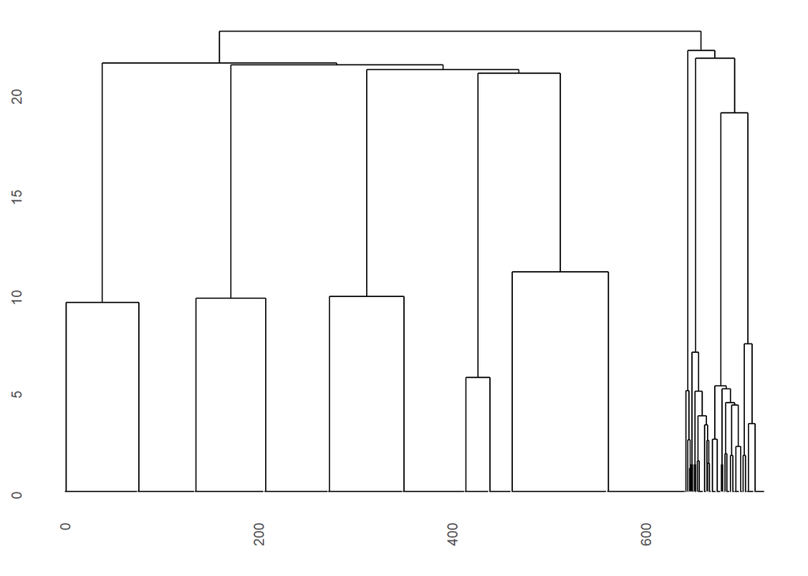

```r
ggdendrogram(arbre, labels = FALSE)
```

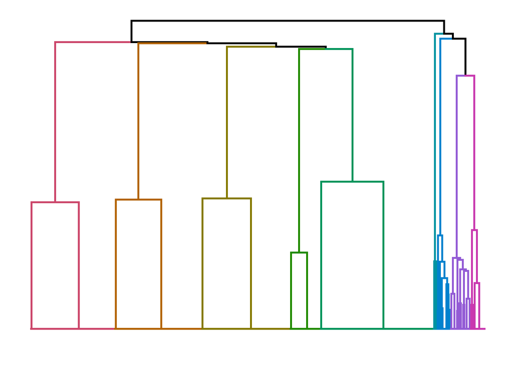

```r
# Coloration des branches en fonction des clusters
library(ggplot2)
ggplot(color_branches(arbre, k = 9), labels = FALSE)
```

## Typologie

```r
typo <- cutree(arbre, 9)
freq(typo)
```

```
## Frequencies
## typo
## Type: Integer
##
##               Freq   % Valid   % Valid Cum.   % Total   % Total Cum.
## ----------- ------ --------- -------------- --------- --------------
##           1    141     19.50          19.50     19.50          19.50
##           2    138     19.09          38.59     19.09          38.59
##           3     48      6.64          45.23      6.64          45.23
##           4    134     18.53          63.76     18.53          63.76
##           5    180     24.90          88.66     24.90          88.66
##           6      6      0.83          89.49      0.83          89.49
##           7     23      3.18          92.67      3.18          92.67
##           8     21      2.90          95.57      2.90          95.57
##           9     32      4.43         100.00      4.43         100.00
##        <NA>      0                               0.00         100.00
##       Total    723    100.00         100.00    100.00         100.00
```

```r
data_interest$typo<- cutree(arbre,9)
```

```r
data_interest %>%
  tbl_summary(by = typo)
```

| **Characteristic** | **1** N = 141<sup>1</sup> | **2** N = 138<sup>1</sup> | **3** N = 48<sup>1</sup> | **4** N = 134<sup>1</sup> | **5** N = 180<sup>1</sup> | **6** N = 6<sup>1</sup> | **7** N = 23<sup>1</sup> | **8** N = 21<sup>1</sup> | **9** N = 32<sup>1</sup> |
| --- | --- | --- | --- | --- | --- | --- | --- | --- | --- |
| Somme_Importance |  |  |  |  |  |  |  |  |  |
| 0 oui (rien n’est important) | 0 (0%) | 0 (0%) | 0 (0%) | 0 (0%) | 0 (0%) | 2 (33%) | 23 (100%) | 3 (14%) | 0 (0%) |
| 1 oui | 0 (0%) | 0 (0%) | 48 (100%) | 0 (0%) | 0 (0%) | 0 (0%) | 0 (0%) | 3 (14%) | 3 (9.4%) |
| 2 oui | 0 (0%) | 0 (0%) | 0 (0%) | 0 (0%) | 180 (100%) | 2 (33%) | 0 (0%) | 7 (33%) | 8 (25%) |
| 3 oui | 141 (100%) | 0 (0%) | 0 (0%) | 0 (0%) | 0 (0%) | 0 (0%) | 0 (0%) | 4 (19%) | 10 (31%) |
| 4 oui | 0 (0%) | 0 (0%) | 0 (0%) | 134 (100%) | 0 (0%) | 2 (33%) | 0 (0%) | 1 (4.8%) | 5 (16%) |
| 5 oui (tout est important) | 0 (0%) | 138 (100%) | 0 (0%) | 0 (0%) | 0 (0%) | 0 (0%) | 0 (0%) | 3 (14%) | 6 (19%) |
| Somme_Importance_subjectif |  |  |  |  |  |  |  |  |  |
| 0 oui (rien n’est important) | 0 (0%) | 0 (0%) | 0 (0%) | 0 (0%) | 0 (0%) | 6 (100%) | 0 (0%) | 0 (0%) | 0 (0%) |
| 1 oui | 0 (0%) | 0 (0%) | 0 (0%) | 0 (0%) | 0 (0%) | 0 (0%) | 0 (0%) | 21 (100%) | 0 (0%) |
| 2 oui | 0 (0%) | 0 (0%) | 0 (0%) | 0 (0%) | 0 (0%) | 0 (0%) | 5 (22%) | 0 (0%) | 32 (100%) |
| 3 oui (tout est important) | 141 (100%) | 138 (100%) | 48 (100%) | 134 (100%) | 180 (100%) | 0 (0%) | 18 (78%) | 0 (0%) | 0 (0%) |
| gpe_age |  |  |  |  |  |  |  |  |  |
| 18-24 ans | 64 (45%) | 66 (48%) | 23 (48%) | 59 (44%) | 81 (45%) | 1 (17%) | 14 (61%) | 15 (71%) | 17 (53%) |
| 25-34 ans | 77 (55%) | 72 (52%) | 25 (52%) | 75 (56%) | 99 (55%) | 5 (83%) | 9 (39%) | 6 (29%) | 15 (47%) |

<sup>1</sup> n (%)

```r
#data_interest
```

# Regression

```r
#  Fonction pour exécuter la régression logistique
#install.packages(c("dplyr", "broom", "ggplot2", "purrr", "forestmodel"))

library(dplyr)
library(broom)
library(ggplot2)
library(purrr)
library(forestmodel)


# Fonction pour exécuter la régression logistique et extraire les résultats
run_logistic_regression <- function(dep_var, indep_vars, model_name, data) {
  formula <- as.formula(paste(dep_var, "~", paste(indep_vars, collapse = " + ")))
  model <- glm(formula, data = data, family = binomial)

  tidy(model, exponentiate = TRUE, conf.int = TRUE) %>%
    mutate(Model = model_name, Dependent = dep_var) %>%
    select(term, estimate, conf.low, conf.high, Model, Dependent)
}
```

```r
# 3 .Forest avec forest_model
#Définition des variables dépendantes et indépendantes
dependent_vars <- c("Quiter_nid_rec", "Emploi_TPL_rec", "Vivre_en_couple_rec",
                    "Marier_1er_fois_rec", "Parent_1er_fois_rec",
                    "Propres_responsabilites_rec", "Propres_decisions_rec",
                    "Independance_finance_rec")

# Liste des modèles logistiques par variable dépendante
models <- lapply(dependent_vars, function(dep_var) {
  list(
    "Modèle 1a" = glm(as.formula(paste(dep_var, "~ Nbr_compte_MS")), data = data_P3_, family = binomial),
    "Modèle 1b" = glm(as.formula(paste(dep_var, "~ Nbr_compte_MS_regulier")), data = data_P3_, family = binomial),
    "Modèle 1c" = glm(as.formula(paste(dep_var, "~ Nbr_compte_MS + Nbr_compte_MS_regulier")), data = data_P3_, family = binomial),
    "Modèle 2"  = glm(as.formula(paste(dep_var, "~ Nbr_compte_MS + Nbr_compte_MS_regulier + gpe_age + sexe + Lieu_de_residence")), data = data_P3_, family = binomial)
  )
})
```

## Forest plot

dependent_vars <- c(“Quiter_nid_rec”, “Emploi_TPL_rec”, “Vivre_en_couple_rec”, “Marier_1er_fois_rec”, “Parent_1er_fois_rec”, “Propres_responsabilites_rec”, “Propres_decisions_rec”, “Independance_finance_rec”)

```
"Modèle 1a" = Nbr_compte_MS"
"Modèle 1b" =  Nbr_compte_MS_regulier
"Modèle 1c" =  Nbr_compte_MS + Nbr_compte_MS_regulier
"Modèle 2"  =  Nbr_compte_MS + Nbr_compte_MS_regulier + gpe_age + sexe + Lieu_de_residence
```

```
##
## --- Forest Plot pour Quiter_nid_rec - Modèle 1a ---
```

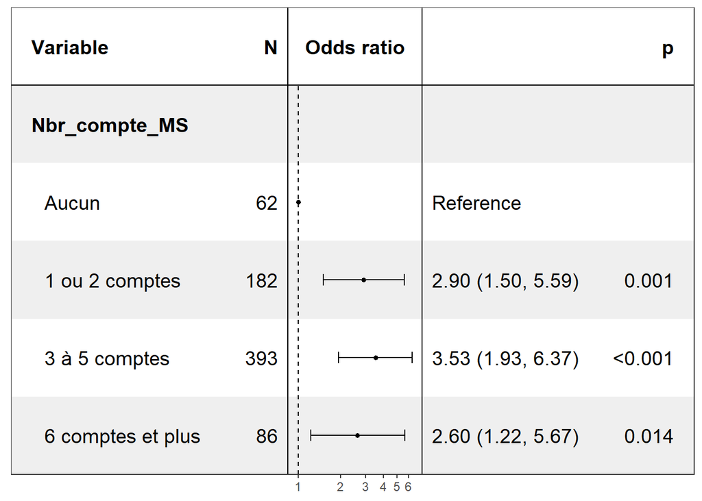

```
##
## --- Forest Plot pour Quiter_nid_rec - Modèle 1b ---
```

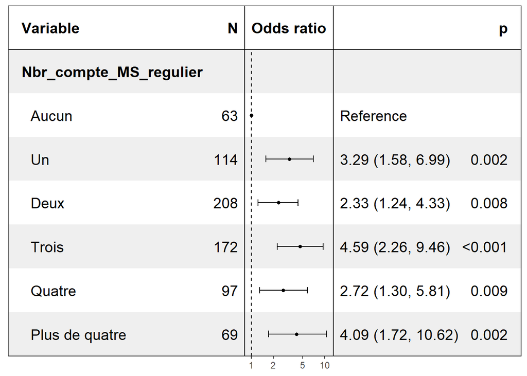

```
##
## --- Forest Plot pour Quiter_nid_rec - Modèle 1c ---
```

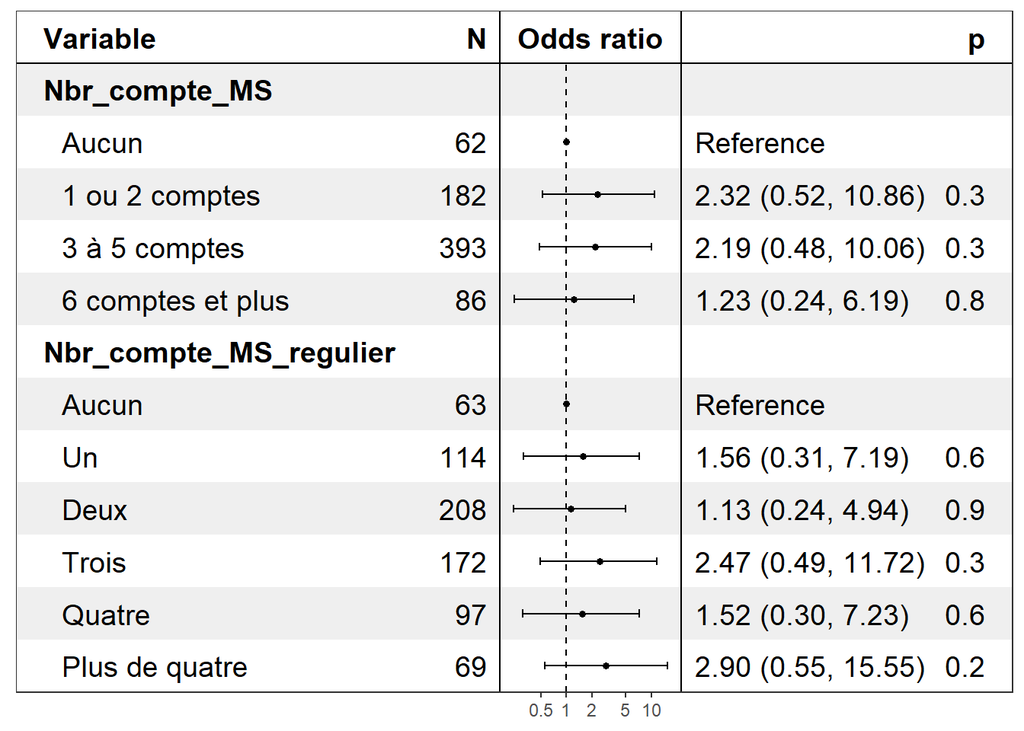

```
##
## --- Forest Plot pour Quiter_nid_rec - Modèle 2 ---
```

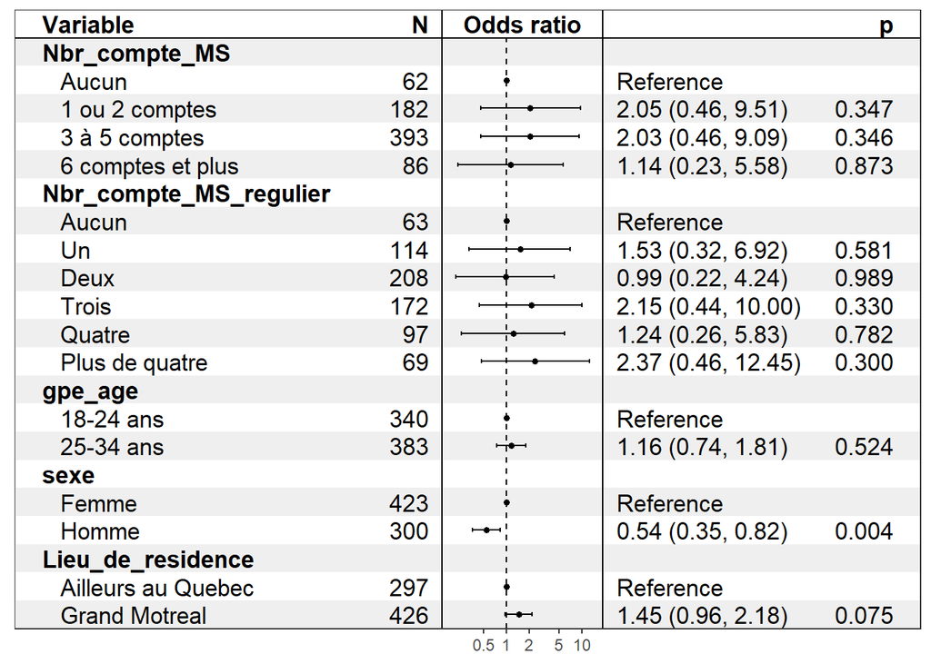

```
##
## --- Forest Plot pour Emploi_TPL_rec - Modèle 1a ---
```

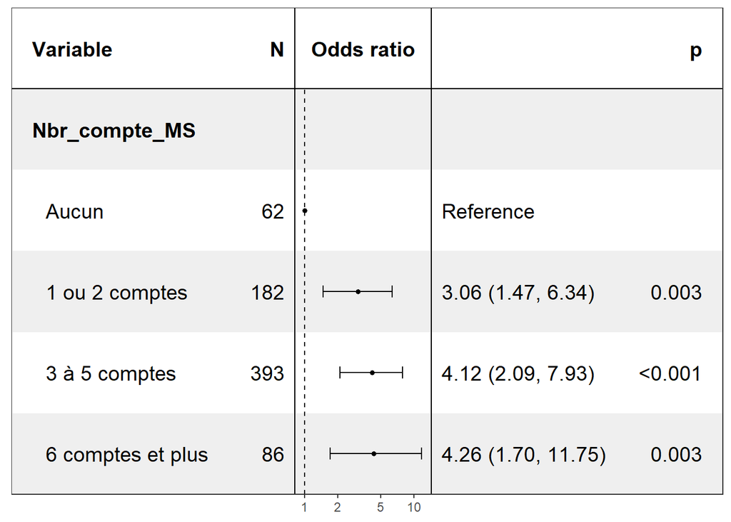

```
##
## --- Forest Plot pour Emploi_TPL_rec - Modèle 1b ---
```

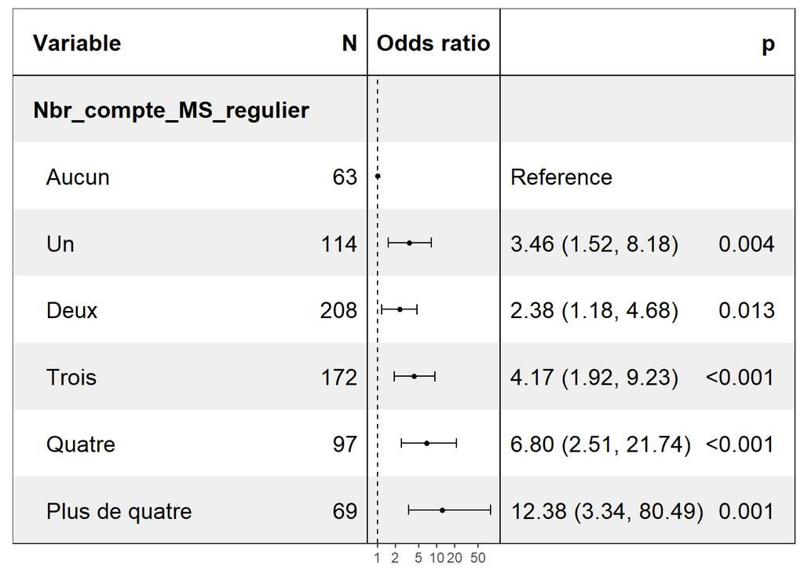

```
##
## --- Forest Plot pour Emploi_TPL_rec - Modèle 1c ---
```

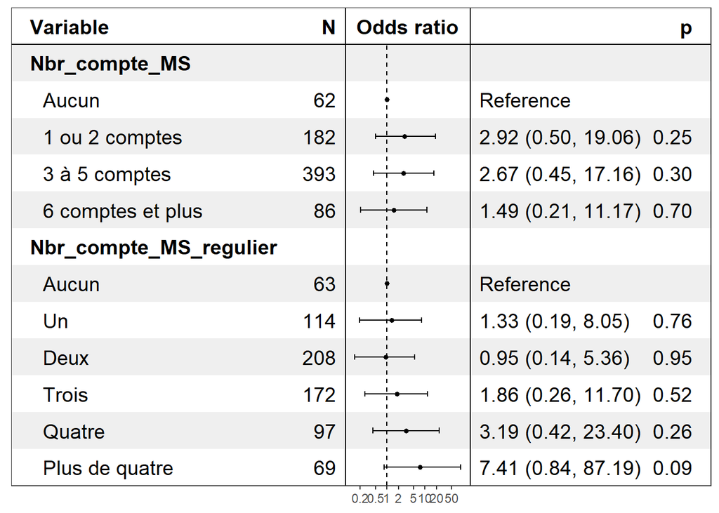

```
##
## --- Forest Plot pour Emploi_TPL_rec - Modèle 2 ---
```

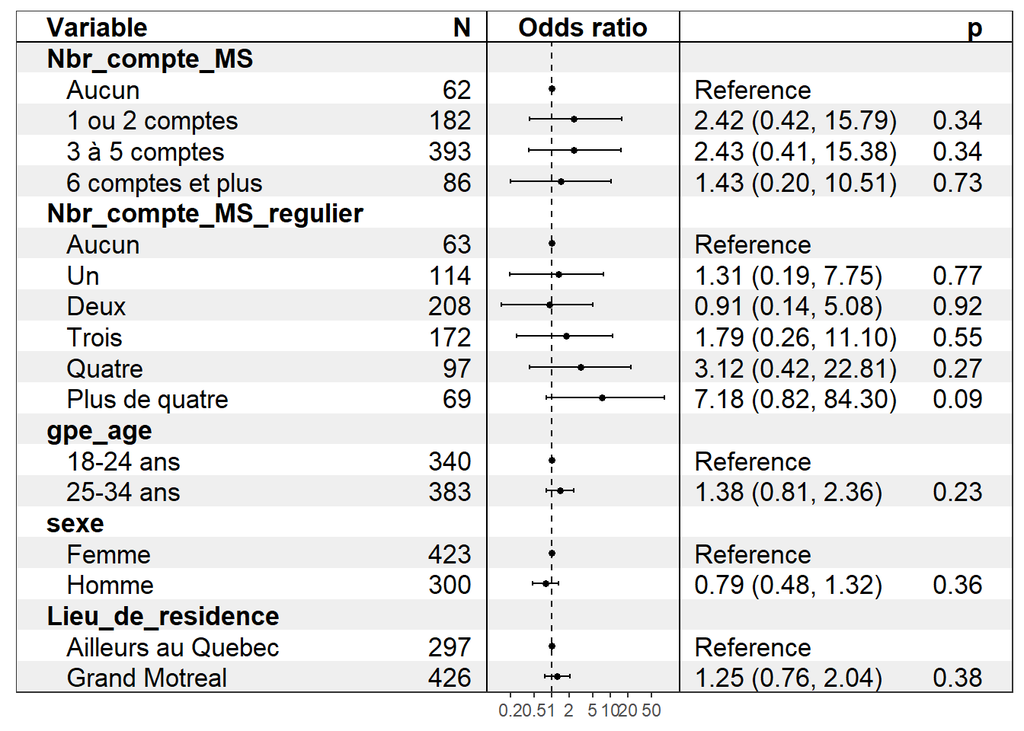

```
##
## --- Forest Plot pour Vivre_en_couple_rec - Modèle 1a ---
```

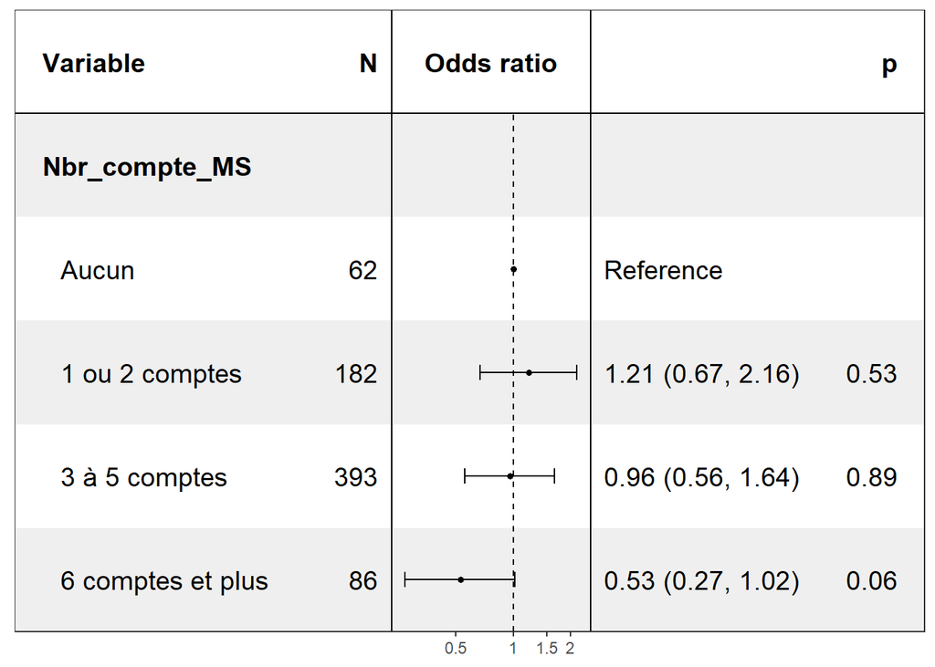

```
##
## --- Forest Plot pour Vivre_en_couple_rec - Modèle 1b ---
```

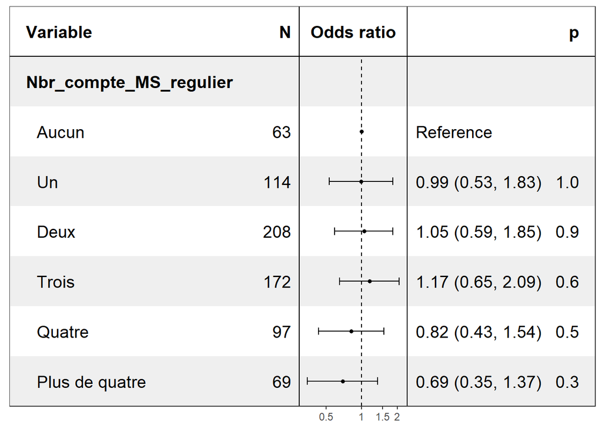

```
##
## --- Forest Plot pour Vivre_en_couple_rec - Modèle 1c ---
```

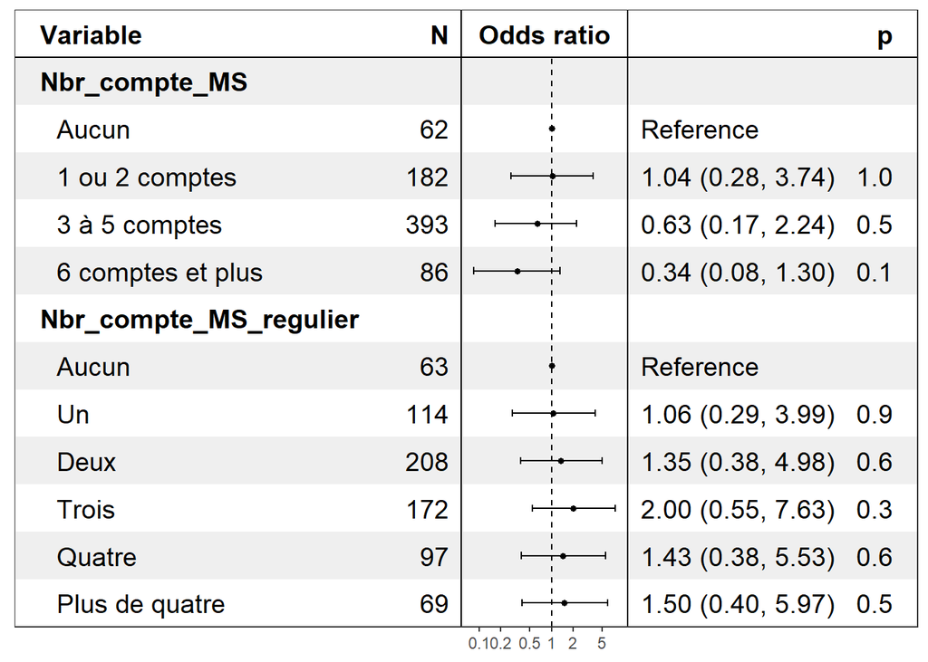

```
##
## --- Forest Plot pour Vivre_en_couple_rec - Modèle 2 ---
```

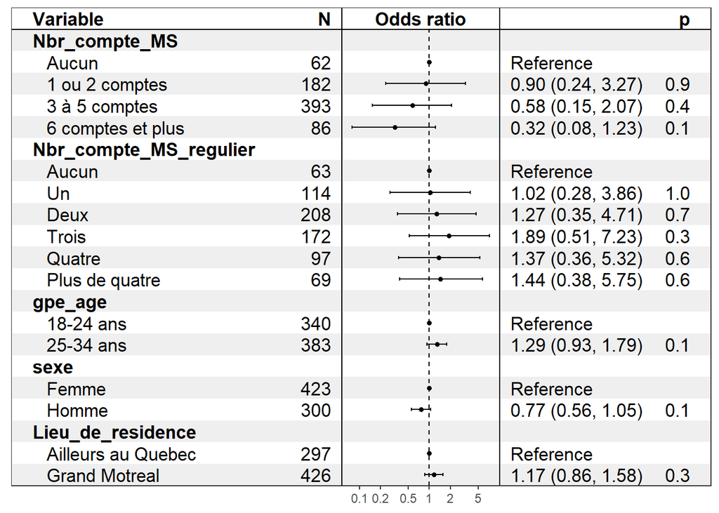

```
##
## --- Forest Plot pour Marier_1er_fois_rec - Modèle 1a ---
```

[52 more figures not shown]

```r
# 3.1. Appliquer forest_model à chaque modèle en ajoutant des options de format
# Appliquer forest_model à chaque modèle en ajoutant des options de format
lapply(seq_along(models), function(i) {
  dep_var <- dependent_vars[i]
  lapply(names(models[[i]]), function(model_name) {
    cat("\n--- Forest Plot pour", dep_var, "-", model_name, "---\n")  # Ajouter un titre clair

    # Générer le Forest Plot avec format ajusté
    print(forest_model(models[[i]][[model_name]], factor_separate_line = T,
                       format_options = list(colour = "black", shape = 20, banded = T,
                                             text_size = 5, point_size = 2)))
  })
})
```

## Regroupement des regression avec stargazer

```r
#install.packages(c("dplyr", "broom", "purrr", "stargazer"))

# Charger les bibliothèques nécessaires
library(dplyr)
library(broom)
library(purrr)
library(stargazer)

# Fonction pour exécuter une régression logistique et retourner le modèle
run_logistic_regression <- function(dep_var, indep_vars, data) {
  formula <- as.formula(paste(dep_var, "~", paste(indep_vars, collapse = " + ")))
  model <- glm(formula, data = data, family = binomial)
  return(model)  # Retourne le modèle au lieu des résultats sous forme de tableau
}

# Définition des variables dépendantes et indépendantes
dependent_vars <- c("Quiter_nid_rec", "Emploi_TPL_rec", "Vivre_en_couple_rec",
                    "Marier_1er_fois_rec", "Parent_1er_fois_rec",
                    "Propres_responsabilites_rec", "Propres_decisions_rec",
                    "Independance_finance_rec")

indep_vars_list <- list(
  "Modèle 1a" = c("Usage_MS"),
  "Modèle 1b" = c("Nbr_compte_MS"),
  "Modèle 1c" = c("Nbr_compte_MS_regulier"),
  "Modèle 1d" = c("Usage_MS", "Nbr_compte_MS", "Nbr_compte_MS_regulier")
)

# Exécuter toutes les régressions et stocker les modèles
models <- list()

for (dep_var in dependent_vars) {
  for (model_name in names(indep_vars_list)) {
    model <- run_logistic_regression(dep_var, indep_vars_list[[model_name]], data_P3_)
    models[[paste(dep_var, model_name, sep = "_")]] <- model
  }
}

# Transformer la liste en un format utilisable par stargazer
models_flat <- unname(models)  # Supprime les noms pour éviter les erreurs


# Générer le tableau avec Stargazer et enregistrer dans le dossier 'rapport' avec 'here'
stargazer(models_flat, type = "html", title = "Résultats des régressions logistiques",
          style = "aer", digits = 2, out = here("rapport", "resultats_regression.html"))
```

[output not shown]

[output cut: 23 more lines]

## Stargazer avec autres variables

```r
#install.packages(c("dplyr", "broom", "purrr", "stargazer"))
# Charger les bibliothèques nécessaires
library(dplyr)
library(broom)
library(purrr)
library(stargazer)

# Fonction pour exécuter une régression logistique et retourner le modèle
run_logistic_regression <- function(dep_var, indep_vars, data) {
  formula <- as.formula(paste(dep_var, "~", paste(indep_vars, collapse = " + ")))
  model <- glm(formula, data = data, family = binomial)
  return(model)  # Retourne le modèle au lieu des résultats sous forme de tableau
}

# Définition des variables dépendantes et indépendantes
dependent_vars <- c("Quiter_nid_rec", "Emploi_TPL_rec", "Vivre_en_couple_rec",
                    "Marier_1er_fois_rec", "Parent_1er_fois_rec",
                    "Propres_responsabilites_rec", "Propres_decisions_rec",
                    "Independance_finance_rec")

indep_vars_list <- list(

  "Modèle 1a" = c("Usage_MS"),

  "Modèle 1b" = c("Usage_MS","age", "sexe", "Lieu_de_residence", "lieu_de_naissance",
                  "Diplome_du_repondant", "Occupation_du_repondant"),


  "Modèle 1c" = c("Usage_MS","age", "sexe", "Lieu_de_residence", "lieu_de_naissance",
                  "Diplome_du_repondant", "Occupation_du_repondant","Diplome_mere", "Diplome_pere", "Situation_civile_parents",
                  "Occupation_mere", "Occupation_pere"),

  "Modèle 1d" = c("Usage_MS","Suivre_activité_amis_et_famille", "Communiquer_amis_et_famille",
                  "Partager_propre_matériel_avec_proches", "Partager_propre_matériel_publiquement",
                  "Suivre_actualités_sur_RSM", "Prendre_connaissance_programmes_gouv",
                  "Rechercher_information_generale", "Rechercher_info_importante_personnelle",
                  "Aucune", "Autre")
)

# Exécuter toutes les régressions et stocker les modèles
models <- list()

for (dep_var in dependent_vars) {
  for (model_name in names(indep_vars_list)) {
    model <- run_logistic_regression(dep_var, indep_vars_list[[model_name]], data_P3_)
    models[[paste(dep_var, model_name, sep = "_")]] <- model
  }
}

# Transformer la liste en un format utilisable par stargazer
models_flat <- unname(models)  # Supprime les noms pour éviter les erreurs


# Générer le tableau avec Stargazer et enregistrer dans le dossier 'rapport' avec 'here'
stargazer(models_flat, type = "html", title = "Résultats des régressions logistiques",
          style = "aer", digits = 2, out = here("rapport", "resultats_regression_1.html"))
```

[output not shown]

[output cut: 150 more lines]

## Forest plot avec sjPlot

### Variable Utilisation des médias

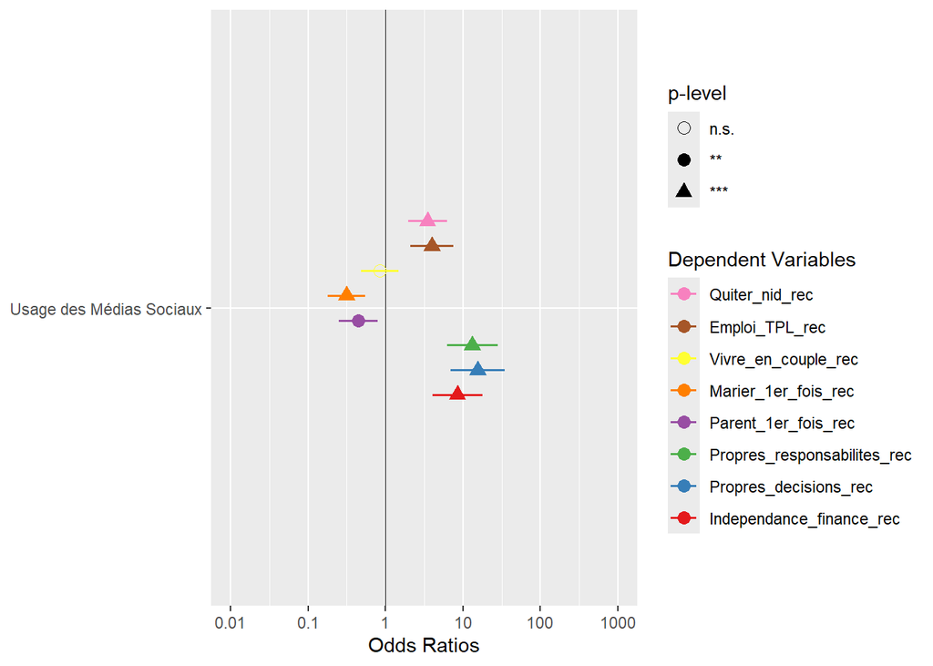

```r
#install.packages("sjPlot")
library(sjPlot)
# Fonction pour générer un modèle logistique
generate_logistic_model <- function(dep_var, indep_var, data) {
  formula <- as.formula(paste(dep_var, "~", indep_var))
  model <- glm(formula, data = data, family = binomial)
  return(model)
}

# Liste des variables dépendantes
dependent_vars <- c("Quiter_nid_rec", "Emploi_TPL_rec", "Vivre_en_couple_rec",
                    "Marier_1er_fois_rec", "Parent_1er_fois_rec",
                    "Propres_responsabilites_rec", "Propres_decisions_rec",
                    "Independance_finance_rec")

# Variable indépendante (Usage_MS uniquement)
indep_vars_1a <- "Usage_MS"

# Créer une liste vide pour stocker les modèles
model_list <- list()
m_labels <- c()  # Liste pour stocker les labels des modèles

# Appliquer les régressions pour chaque variable dépendante
for (dep_var in dependent_vars) {
  model_list[[paste0(dep_var, "_Usage_MS")]] <- generate_logistic_model(dep_var, indep_vars_1a, data_P3_)

  # Ajouter les labels incrémentés dans m_labels
  m_labels <- c(m_labels, paste0(dep_var, ""))  # Label pour Usage_MS uniquement
}

# Vérification des modèles et des labels
#print(names(model_list))  # Afficher les noms des modèles
#print(m_labels)  # Afficher les labels

# Appliquer plot_models avec les modèles et les labels
plot_models(
  model_list,
  axis.labels = c("Usage des Médias Sociaux"),  # Seule variable indépendante
  m.labels = m_labels,  # Utilisation des labels incrémentés
  show.values = FALSE,  # Ne pas afficher les valeurs numériques des coefficients
  show.p = FALSE,  # Ne pas afficher les p-valeurs
  p.shape = TRUE,  # Afficher les formes des points au lieu des valeurs
   vline.color = "black",
  grid = F# Afficher une grille
)
```

```r
# Générer le graphique et enregistrer dans le dossier 'figures/forestplot'
ggsave(here("figures", "forestplot", "Utilisation des médias_forestplot.png"),
       plot = last_plot(), width = 10, height = 6)
```

### nombre de de compte des médias

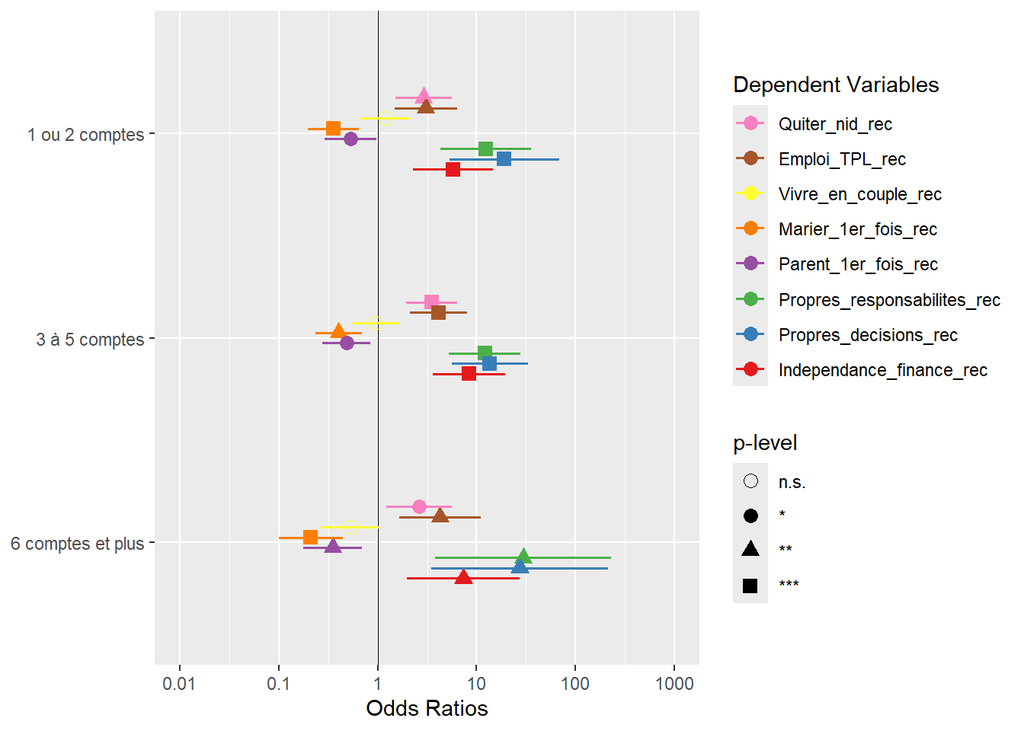

```r
# Fonction pour générer un modèle logistique
generate_logistic_model <- function(dep_var, indep_var, data) {
  formula <- as.formula(paste(dep_var, "~", indep_var))
  model <- glm(formula, data = data, family = binomial)
  return(model)
}

# Liste des variables dépendantes
dependent_vars <- c("Quiter_nid_rec", "Emploi_TPL_rec", "Vivre_en_couple_rec",
                    "Marier_1er_fois_rec", "Parent_1er_fois_rec",
                    "Propres_responsabilites_rec", "Propres_decisions_rec",
                    "Independance_finance_rec")

# Variable indépendante : Nombre de Comptes MS
indep_vars_1b <- "Nbr_compte_MS"  # Ajout de "Nbr_compte_MS"

# Créer une liste vide pour stocker les modèles
model_list <- list()
m_labels <- c()  # Liste pour stocker les labels des modèles

# Appliquer les régressions pour chaque variable dépendante
for (dep_var in dependent_vars) {
  model_list[[paste0(dep_var, "_Nbr_compte_MS")]] <- generate_logistic_model(dep_var, indep_vars_1b, data_P3_)

  # Ajouter les labels incrémentés dans m_labels
  m_labels <- c(m_labels,
                paste0(dep_var, ""))  # Label pour Nbr_compte_MS
}

# Vérification des modèles et des labels
#print(names(model_list))  # Afficher les noms des modèles
#print(m_labels)  # Afficher les labels

# Appliquer plot_models avec les modèles et les labels

plot_models(
  model_list,
  m.labels = m_labels,  # Utilisation des labels incrémentés
  show.values = FALSE,  # Ne pas afficher les valeurs numériques des coefficients
  show.p = FALSE,  # Ne pas afficher les p-valeurs
  p.shape = TRUE,
  show.legend = TRUE,# Afficher les formes des points au lieu des valeurs
  grid =F,   #Afficher une grille
   vline.color = "black"
)
```

```r
# Générer le graphique et enregistrer dans le dossier 'figures/forestplot'
ggsave(here("figures", "forestplot", "nombre de de compte des médias_forestplot.png"),
       plot = last_plot(), width = 10, height = 6)
```

### Variable utilisation de compte regulier

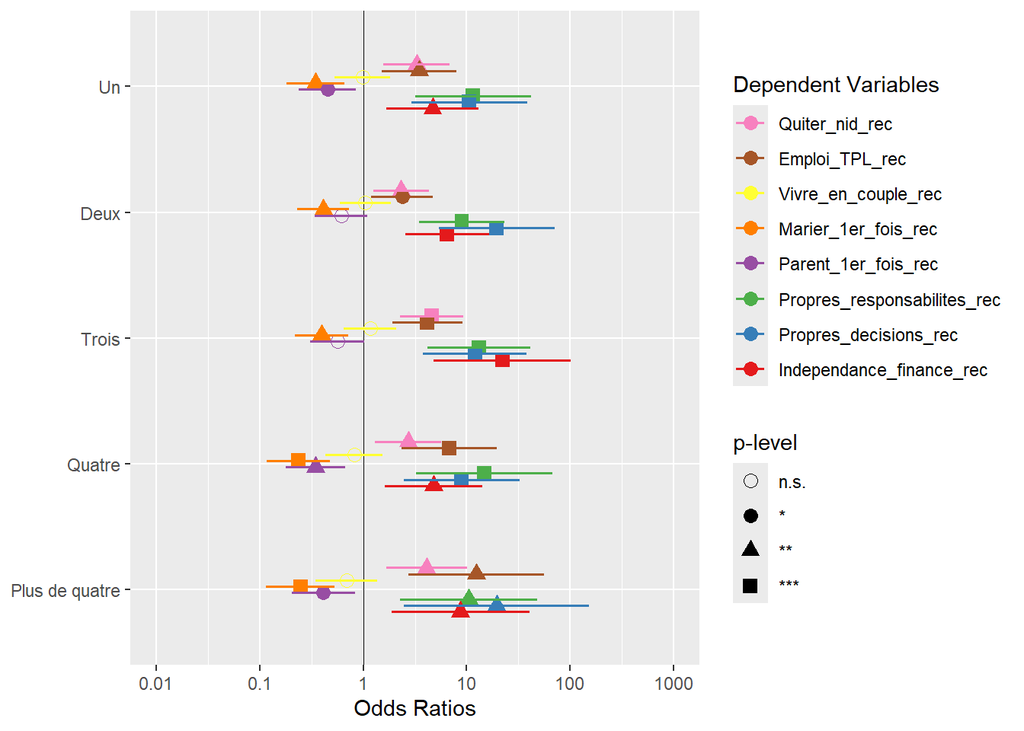

```r
# Fonction pour générer un modèle logistique
generate_logistic_model <- function(dep_var, indep_var, data) {
  formula <- as.formula(paste(dep_var, "~", indep_var))
  model <- glm(formula, data = data, family = binomial)
  return(model)
}

# Liste des variables dépendantes
dependent_vars <- c("Quiter_nid_rec", "Emploi_TPL_rec", "Vivre_en_couple_rec",
                    "Marier_1er_fois_rec", "Parent_1er_fois_rec",
                    "Propres_responsabilites_rec", "Propres_decisions_rec",
                    "Independance_finance_rec")

# Variable indépendante : Nombre de Comptes MS Régulier
indep_vars_1c <- "Nbr_compte_MS_regulier"  # Remplacement par "Nbr_compte_MS_regulier"

# Créer une liste vide pour stocker les modèles
model_list <- list()
m_labels <- c()  # Liste pour stocker les labels des modèles

# Appliquer les régressions pour chaque variable dépendante
for (dep_var in dependent_vars) {
  model <- generate_logistic_model(dep_var, indep_vars_1c, data_P3_)
  model_list[[paste0(dep_var, "_Nbr_compte_MS_regulier")]] <- model

  # Ajouter les labels incrémentés dans m_labels
  m_labels <- c(m_labels,
                paste0(dep_var, ""))  # Label pour Nbr_compte_MS_regulier

  # Afficher les résultats de la régression pour chaque modèle
  #cat("\nRésultats de la régression pour", dep_var, "avec Nbr_compte_MS_regulier:\n")
  #print(summary(model))  # Afficher le résumé du modèle
}

# Vérification des modèles et des labels
#print(names(model_list))  # Afficher les noms des modèles
#print(m_labels)  # Afficher les labels

# Appliquer plot_models avec les modèles et les labels
plot_models(
  model_list,
    # Ajout de Nbr_compte_MS_regulier
  m.labels = m_labels,  # Utilisation des labels incrémentés
  show.values = FALSE,  # Ne pas afficher les valeurs numériques des coefficients
  show.p = FALSE,  # Ne pas afficher les p-valeurs
  p.shape = TRUE,  # Afficher les formes des points au lieu des valeurs
  grid = F,  # Afficher une grille
  vline.color = "black"
)
```

```r
# Générer le graphique et enregistrer dans le dossier 'figures/forestplot'
ggsave(here("figures", "forestplot", "nombre de de compte regulier_forestplot.png"),
       plot = last_plot(), width = 10, height = 6)
```

### Nombre d’heure par Jour

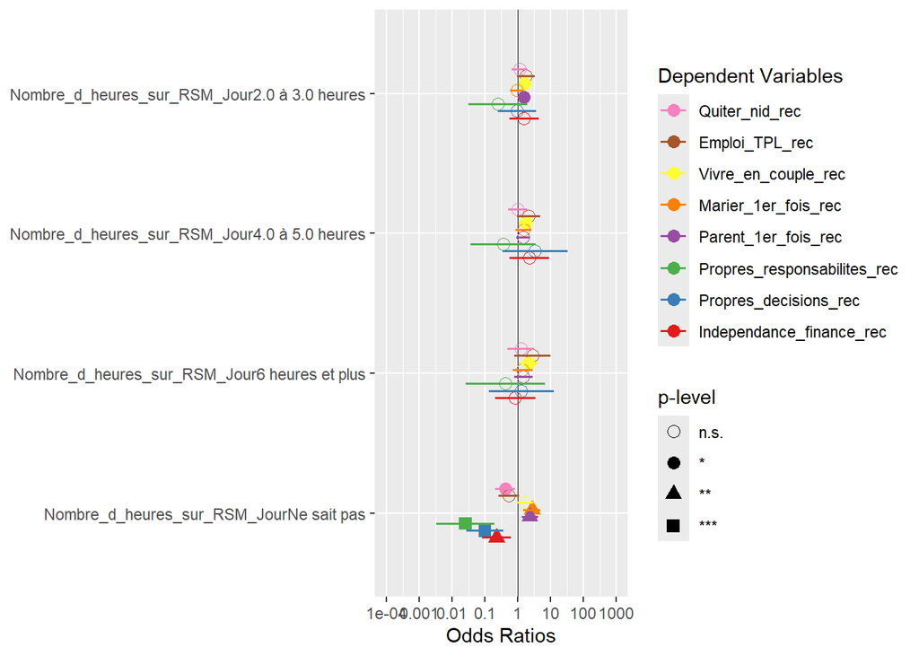

```r
library(sjPlot)
library(ggplot2)
library(here)

# Fonction pour générer un modèle logistique
generate_logistic_model <- function(dep_var, indep_var, data) {
  formula <- as.formula(paste(dep_var, "~", indep_var))
  model <- glm(formula, data = data, family = binomial)
  return(model)
}

# Liste des variables dépendantes
dependent_vars <- c("Quiter_nid_rec", "Emploi_TPL_rec", "Vivre_en_couple_rec",
                    "Marier_1er_fois_rec", "Parent_1er_fois_rec",
                    "Propres_responsabilites_rec", "Propres_decisions_rec",
                    "Independance_finance_rec")

# Variable indépendante
indep_vars_1b <- "Nombre_d_heures_sur_RSM_Jour"

# Stockage des modèles et labels
model_list <- list()
m_labels <- c()

# Boucle pour ajuster les modèles logistiques
for (dep_var in dependent_vars) {
  model_list[[dep_var]] <- generate_logistic_model(dep_var, indep_vars_1b, data_P3_)
  m_labels <- c(m_labels, dep_var)
}

# Génération du graphique avec un style uniforme
p <- plot_models(
  model_list,
  m.labels = m_labels,
  show.values = FALSE,
  show.p = FALSE,
  show.legend = T,
  p.shape = T,
  grid = F,
  vline.color = "black"
)


# Enregistrement du graphique
ggsave(here("figures", "forestplot", "nombre_d_heures_sur_RSM_Jour_forestplot.png"),
       plot = p, width = 10, height = 6)

p
```

### variables concernant les médias

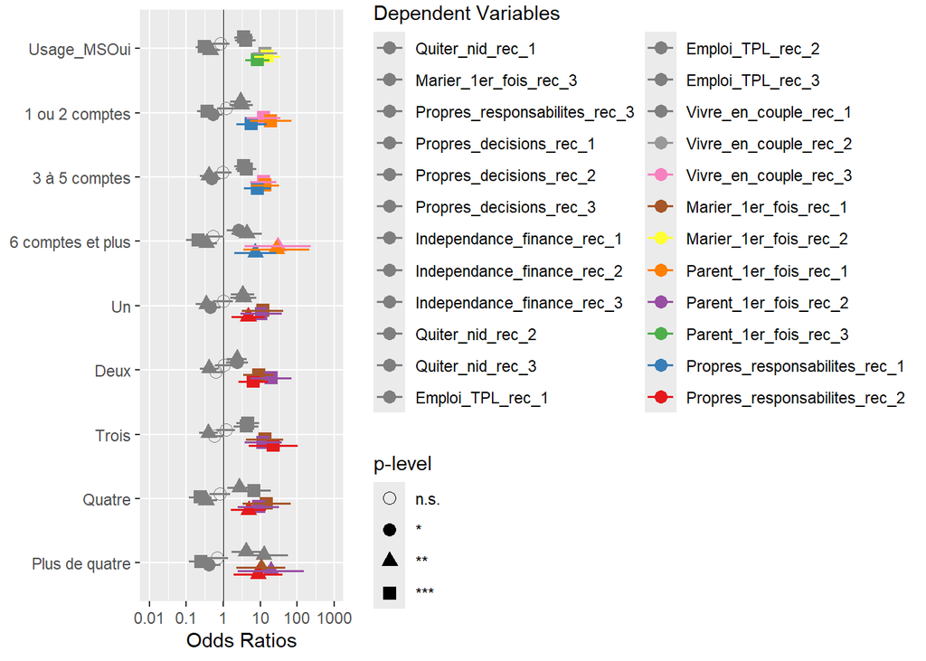

```r
# Fonction pour générer un modèle logistique
generate_logistic_model <- function(dep_var, indep_var, data) {
  formula <- as.formula(paste(dep_var, "~", indep_var))
  model <- glm(formula, data = data, family = binomial)
  return(model)
}

# Liste des variables dépendantes
dependent_vars <- c("Quiter_nid_rec", "Emploi_TPL_rec", "Vivre_en_couple_rec",
                    "Marier_1er_fois_rec", "Parent_1er_fois_rec",
                    "Propres_responsabilites_rec", "Propres_decisions_rec",
                    "Independance_finance_rec")

# Variables indépendantes
indep_vars_1a <- "Usage_MS"
indep_vars_1b <- "Nbr_compte_MS"
indep_vars_1c <- "Nbr_compte_MS_regulier"

# Créer une liste vide pour stocker les modèles
model_list <- list()
m_labels <- c()  # Liste pour stocker les labels des modèles

# Appliquer les régressions pour chaque variable dépendante
for (dep_var in dependent_vars) {
  model_list[[paste0(dep_var, "_Usage_MS")]] <- generate_logistic_model(dep_var, indep_vars_1a, data_P3_)
  model_list[[paste0(dep_var, "_Nbr_compte_MS")]] <- generate_logistic_model(dep_var, indep_vars_1b, data_P3_)
  model_list[[paste0(dep_var, "_Nbr_compte_MS_regulier")]] <- generate_logistic_model(dep_var, indep_vars_1c, data_P3_)

  # Ajouter les labels incrémentés dans m_labels
  m_labels <- c(m_labels,
                paste0(dep_var, "_1"),  # Label pour Usage_MS
                paste0(dep_var, "_2"),  # Label pour Nbr_compte_MS
                paste0(dep_var, "_3"))  # Label pour Nbr_compte_MS_regulier
}

# Vérification des modèles et des labels
#print(names(model_list))  # Afficher les noms des modèles
#print(m_labels)  # Afficher les labels

# Appliquer plot_models avec les modèles et les labels
plot_models(
  model_list,
    # Sans la combinaison
  m.labels = m_labels,  # Utilisation des labels incrémentés
  show.values = FALSE,  # Ne pas afficher les valeurs numériques des coefficients
  show.p = FALSE,  # Ne pas afficher les p-valeurs
  p.shape = T,  # Afficher les formes des points au lieu des valeurs
  show.legend = T,
  grid = F,  # Afficher une grille
  vline.color = "black"
)
```

```r
# Générer le graphique et enregistrer dans le dossier 'figures/forestplot'
ggsave(here("figures", "forestplot", "Toute _les variables_utilisation des médias_forestplot.png"),
       plot = last_plot(), width = 10, height = 6)
```

### Inversion des axes pour la variables Utilisation des médias sociaux

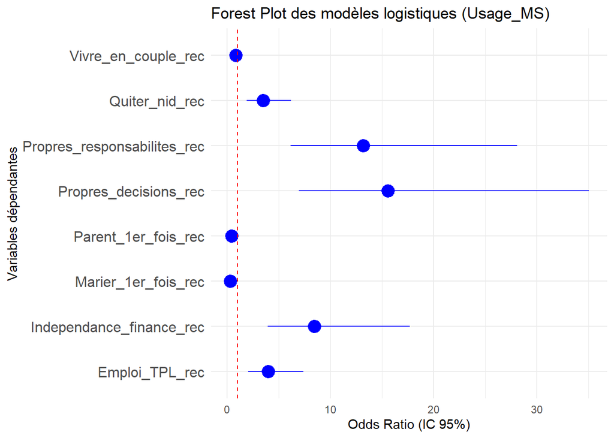

```r
library(gtsummary)
library(dplyr)
library(ggplot2)


# Fonction pour générer un modèle logistique
generate_logistic_model <- function(dep_var, indep_var, data) {
  formula <- as.formula(paste(dep_var, "~", indep_var))
  model <- glm(formula, data = data, family = binomial)
  return(model)
}

# Liste des variables dépendantes
dependent_vars <- c("Quiter_nid_rec", "Emploi_TPL_rec", "Vivre_en_couple_rec",
                    "Marier_1er_fois_rec", "Parent_1er_fois_rec",
                    "Propres_responsabilites_rec", "Propres_decisions_rec",
                    "Independance_finance_rec")

# Variable indépendante (Usage_MS uniquement)
indep_vars_1a <- "Usage_MS"

# Data frame pour stocker les résultats issus de gtsummary
results_df <- data.frame()

# Boucle sur chaque variable dépendante
for (dep in dependent_vars) {
  mod <- generate_logistic_model(dep, indep_vars_1a, data_P3_)

  # Création du tableau de régression avec gtsummary
  tbl <- tbl_regression(mod, exponentiate = TRUE)

  # Extraction du tableau sous forme de data frame et filtrage pour garder uniquement Usage_MS
  tb <- tbl$table_body %>%
    filter(variable == indep_vars_1a) %>%
    mutate(outcome = dep)  # Ajout du nom de la variable dépendante

  # Ajout au data frame final
  results_df <- bind_rows(results_df, tb)
}

# Visualisation : Forest Plot des Odds Ratios pour Usage_MS sur chaque résultat
ggplot(results_df, aes(x = outcome, y = estimate, ymin = conf.low, ymax = conf.high)) +
  geom_pointrange(color = "blue", size = 1) +
  geom_hline(yintercept = 1, linetype = "dashed", color = "red") +  # Référence : OR = 1
  coord_flip() +
  theme_minimal() +
  labs(title = "Forest Plot des modèles logistiques (Usage_MS)",
       x = "Variables dépendantes",
       y = "Odds Ratio (IC 95%)") +
  theme(axis.text.y = element_text(size = 12))
```

```r
# Sauvegarde du graphique
ggsave(here("figures", "forestplot", "Utilisation_des_medias_forestplot_gtsummary.png"),
       width = 10, height = 6)
```

### Comparaion des modeles —–A normaliser d’abord avant de pouvoir comparer

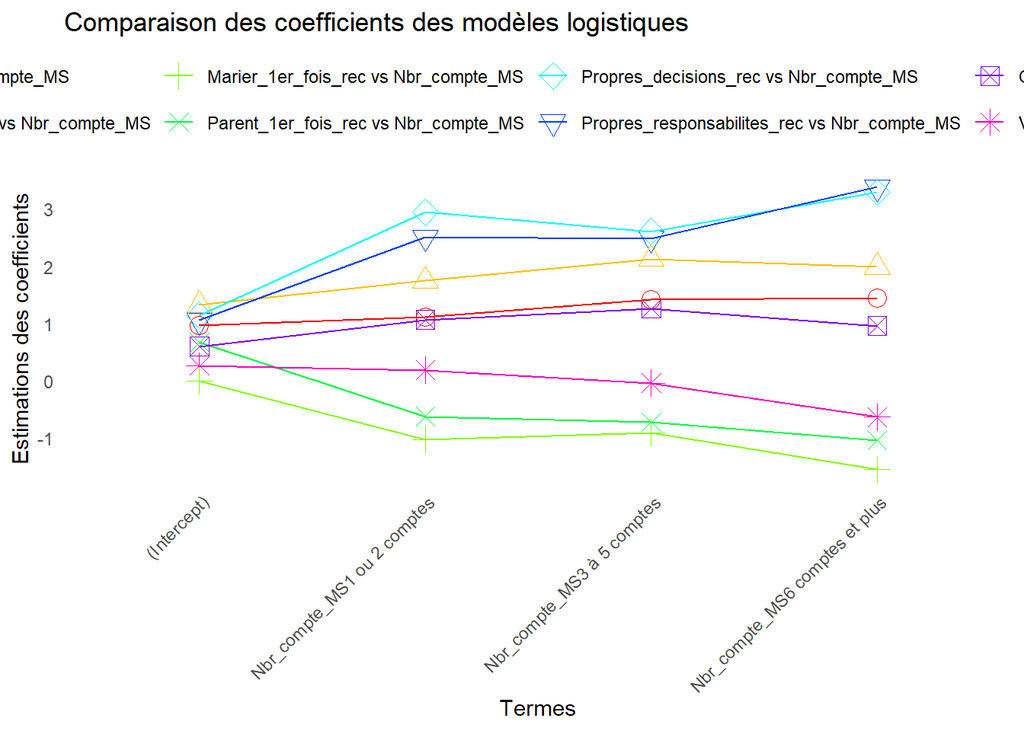

```r
library(ggplot2)
library(broom)
library(dplyr)

# Fonction pour générer un modèle logistique
generate_logistic_model <- function(dep_var, indep_var, data) {
  formula <- as.formula(paste(dep_var, "~", indep_var))
  model <- glm(formula, data = data, family = binomial)
  return(model)
}

# Liste des variables dépendantes
dependent_vars <- c("Quiter_nid_rec", "Emploi_TPL_rec", "Vivre_en_couple_rec",
                    "Marier_1er_fois_rec", "Parent_1er_fois_rec",
                    "Propres_responsabilites_rec", "Propres_decisions_rec",
                    "Independance_finance_rec")

# Variable indépendante : Nombre de Comptes MS
indep_vars_1b <- "Nbr_compte_MS"

# Créer une liste vide pour stocker les modèles
model_list <- list()
m_labels <- c()  # Liste pour stocker les labels des modèles

# Appliquer les régressions pour chaque variable dépendante et récupérer les coefficients
for (dep_var in dependent_vars) {
  model <- generate_logistic_model(dep_var, indep_vars_1b, data_P3_)
  model_list[[paste0(dep_var, "_Nbr_compte_MS")]] <- model
  m_labels <- c(m_labels, paste(dep_var, "vs Nbr_compte_MS"))
}

# Extraire les coefficients des modèles
results <- lapply(seq_along(model_list), function(i) {
  tidy(model_list[[i]]) %>%
    mutate(model = m_labels[i])  # Ajouter le label pour chaque modèle
}) %>%
  bind_rows()  # Combiner tous les résultats en un seul data frame

# Créer le graphique avec ggplot2
ggplot(results, aes(x = term, y = estimate, color = model, shape = model)) +
  geom_point(size = 4) +  # Afficher les points pour chaque estimation de coefficient
  geom_line(aes(group = model), linetype = "solid") +  # Relier les points entre eux pour chaque modèle
  scale_shape_manual(values = 1:length(m_labels)) +  # Attribuer des formes uniques pour chaque modèle
  scale_color_manual(values = rainbow(length(m_labels))) +  # Couleurs personnalisées pour chaque modèle
  labs(x = "Termes", y = "Estimations des coefficients", title = "Comparaison des coefficients des modèles logistiques") +
  theme_minimal() +
  theme(
    legend.position = "top",  # Légende en haut
    axis.text.x = element_text(angle = 45, hjust = 1),  # Rotation des labels des termes
    panel.grid.major = element_blank(),  # Pas de grille principale
    panel.grid.minor = element_blank(),  # Pas de grille mineure
    legend.title = element_blank()  # Enlever le titre de la légende
  )
```

```r
# Marqueur objectifs
# Définition de la fonction
transform_values <- function(x) {
  ifelse(is.na(x), x, ifelse(x == 0, 6, x * 12))
}

# Application des transformations
data_P3_$nbre_annee_depart_maison <- transform_values(data_P3_$nbre_annee_depart_maison)
data_P3_$nbre_annee_depart_vivre_avec_conjoint <- transform_values(data_P3_$nbre_annee_depart_vivre_avec_conjoint)
data_P3_$nbre_annees_depuis_la_naissance_du_1er_enfant <- transform_values(data_P3_$nbre_annees_depuis_la_naissance_du_1er_enfant)
data_P3_$nbre_annee_depuis_commencent_travail <- transform_values(data_P3_$nbre_annee_depuis_commencent_travail)

# Remplacement des NA par des valeurs spécifiques
data_P3_$nbre_annee_depart_maison[is.na(data_P3_$nbre_annee_depart_maison)] <- "Pas_quitter_maison_familial"
data_P3_$nbre_annee_depart_vivre_avec_conjoint[is.na(data_P3_$nbre_annee_depart_vivre_avec_conjoint)] <- "Jamais_vecu_conjoint_12mois"
data_P3_$nbre_annees_depuis_la_naissance_du_1er_enfant[is.na(data_P3_$nbre_annees_depuis_la_naissance_du_1er_enfant)] <- "pas_eu_1er_d'enfant"
data_P3_$nbre_annee_depuis_commencent_travail[is.na(data_P3_$nbre_annee_depuis_commencent_travail)] <- "Pas_encore_emploi"
```

```r
data_P3_$nbre_mois_retour_nid_familial_1ere_fois <- data_P3_$`BC2Q2H[SQ001]`
data_P3_$nbre_mois_retour_nid_familial_1ere_fois[is.na(data_P3_$nbre_mois_retour_nid_familial_1ere_fois)] <- "Pas_revenu_chez_parent"
```

```r
# Création de la nouvelle variable sans écraser l'ancienne
data_P3_$nbre_année_marié_1er_fois <- data_P3_$BC2Q2F

# Remplacement des 0 par 6
data_P3_$nbre_année_marié_1er_fois[data_P3_$nbre_année_marié_1er_fois == 0] <- 6

# Transformation des autres valeurs (2023 - valeur) * 12
data_P3_$nbre_année_marié_1er_fois <- ifelse(
  data_P3_$nbre_année_marié_1er_fois != 6 & !is.na(data_P3_$nbre_année_marié_1er_fois),
  (2023 - data_P3_$nbre_année_marié_1er_fois) * 12,
  data_P3_$nbre_année_marié_1er_fois
)

# Remplacement des NA par "Pas encore marié"
data_P3_$nbre_année_marié_1er_fois[is.na(data_P3_$nbre_année_marié_1er_fois)] <- "Pas_encore_marié"
```

# Recodage generale marqueurs subjectifs

```r
# Remplacement des 0 par 6 et multiplication des autres valeurs par 12
transform_values <- function(x) {
  ifelse(is.na(x), x, ifelse(x == 0, 6, x * 12))
}

# Appliquer la transformation aux trois variables
data_P3_$nbre_annee_depuis_independant_financierement <- transform_values(data_P3_$nbre_annee_depuis_independant_financierement)
data_P3_$nbre_annee_depuis_prendre_propes_decisionsl <- transform_values(data_P3_$nbre_annee_depuis_prendre_propes_decisionsl)
data_P3_$nbre_annee_depuis_prendre_propes_resondabilitésl <- transform_values(data_P3_$nbre_annee_depuis_prendre_propes_resondabilitésl)

# Remplacement des NA par des valeurs spécifiques
data_P3_$nbre_annee_depuis_prendre_propes_resondabilitésl[is.na(data_P3_$nbre_annee_depuis_prendre_propes_resondabilitésl)] <- "Pas_accepter_propres_responsabilités"
data_P3_$nbre_annee_depuis_prendre_propes_decisionsl[is.na(data_P3_$nbre_annee_depuis_prendre_propes_decisionsl)] <- "Pas_capable_prendre_propres_décisions"
data_P3_$nbre_annee_depuis_independant_financierement[is.na(data_P3_$nbre_annee_depuis_independant_financierement)] <- "Pas_indépendant_financièrement"
```

```r
#Classement des marqueurs  objectifs jugés plus important selon les individus
# Définir les noms des colonnes de score
score_vars <- c("Importance_quiter_nid", "Importance_emploi_TPL",
                "Importance_vivre_en_couple", "Importance_marie_1er_fois",
                "Importance_parent_1er_fois")

# Vérifier que ces colonnes existent dans data_P3_
if(!all(score_vars %in% names(data_P3_))){
  stop("Certaines colonnes de scores ne sont pas présentes dans data_P3_. Vérifie les noms exacts.")
}

# S'assurer que les colonnes de score sont de type numérique
data_P3_[, score_vars] <- lapply(data_P3_[, score_vars], function(x) as.numeric(as.character(x)))

# Créer une copie de data_P3_ pour ne pas écraser les données originales
data_marqueur <- data_P3_

# Pour chaque individu, parcourir les marqueurs et retenir le ou les marqueurs ayant la valeur maximale
data_marqueur$Marqueur_plus_important <- apply(data_marqueur[, score_vars], 1, function(x) {
  max_val <- -Inf      # Initialisation avec une valeur très basse
  markers <- c()       # Vecteur pour stocker les noms des marqueurs
  for(i in seq_along(x)) {
    if(x[i] > max_val) {
      max_val <- x[i]
      markers <- names(x)[i]  # Nouveau maximum trouvé, on réinitialise la liste
    } else if(x[i] == max_val) {
      markers <- c(markers, names(x)[i])  # Valeur égale, on ajoute le marqueur à la liste
    }
  }
  # Enlever les doublons (au cas où) et retourner les marqueurs séparés par une virgule
  paste(unique(markers), collapse = ", ")
})

# Afficher un aperçu du résultat

#View(data_marqueur %>% select(Importance_quiter_nid,Importance_emploi_TPL,
                            #Importance_vivre_en_couple,Importance_marie_1er_fois,
                             #Importance_parent_1er_fois,Marqueur_plus_important))
head(data_marqueur[, c(score_vars, "Marqueur_plus_important")])
```

```
## # A tibble: 6 × 6
##   Importance_quiter_nid Importance_emploi_TPL Importance_vivre_en_couple
##                   <dbl>                 <dbl>                      <dbl>
## 1                     2                     2                          3
## 2                     3                     5                          4
## 3                     1                     5                          1
## 4                     3                     5                          4
## 5                     3                     4                          1
## 6                     4                     3                          3
## # ℹ 3 more variables: Importance_marie_1er_fois <dbl>,
## #   Importance_parent_1er_fois <dbl>, Marqueur_plus_important <chr>
```

```r
#Classement des marqueurs  subjectifs jugés plus important selon les individus
# Définir les noms des colonnes subjectives
subj_vars <- c("Importance_independant_finance", "Importance_propres_decisions",
               "Importance_propres_responsabilites")

# Vérifier que ces colonnes existent dans data_P3_
if(!all(subj_vars %in% names(data_P3_))){
  stop("Certaines colonnes subjectives ne sont pas présentes dans data_P3_. Vérifie les noms exacts.")
}

# S'assurer que les colonnes subjectives sont de type numérique
data_P3_[, subj_vars] <- lapply(data_P3_[, subj_vars], function(x) as.numeric(as.character(x)))

# Créer une nouvelle base de données pour les variables subjectives
data_marqueur_subj <- data_P3_

# Pour chaque individu, parcourir les variables subjectives et retenir le ou les marqueur(s) avec la note maximale
data_marqueur_subj$Marqueur_plus_important_subj <- apply(data_marqueur_subj[, subj_vars], 1, function(x) {
  max_val <- -Inf      # Initialisation avec une valeur très basse
  markers <- c()       # Vecteur pour stocker les noms des marqueurs subjectifs
  for(i in seq_along(x)) {
    if(x[i] > max_val) {
      max_val <- x[i]
      markers <- names(x)[i]  # Nouveau maximum trouvé, on réinitialise la liste
    } else if(x[i] == max_val) {
      markers <- c(markers, names(x)[i])  # En cas d'égalité, on ajoute le marqueur
    }
  }
  # Concaténer les marqueurs trouvés, en éliminant d'éventuels doublons
  paste(unique(markers), collapse = ", ")
})

# Afficher un aperçu du résultat
#View(data_marqueur_subj[, c(subj_vars, "Marqueur_plus_important_subj")])
```

# Analyse de séquences

## Analyse de séquences des variables subjectifs

```r
# Définir les noms des colonnes subjectives
subj_vars <- c("Importance_independant_finance",
               "Importance_propres_decisions",
               "Importance_propres_responsabilites")

# Vérifier l'existence des colonnes
if (!all(subj_vars %in% names(data_P3_))) {
  stop("Certaines colonnes subjectives ne sont pas présentes dans data_P3_.")
}

# S'assurer que les colonnes sont numériques
data_P3_[, subj_vars] <- lapply(data_P3_[, subj_vars], function(x) as.numeric(as.character(x)))

# Fonction pour trier les noms des variables selon les règles demandées
ordonner_par_valeur_et_nom <- function(x) {
  valeurs <- as.numeric(x)
  noms <- names(x)

  # Trier en ordre décroissant de valeur, puis alphabétique
  classement <- noms[order(-valeurs, noms)]

  paste(classement, collapse = " | ")  # tu peux changer le séparateur si tu veux
}

# Appliquer la fonction ligne par ligne
data_P3_$Marqueurs_ordonnés_subj <- apply(data_P3_[, subj_vars], 1, ordonner_par_valeur_et_nom)

# Aperçu
#View(data_P3_[, c(subj_vars, "Marqueurs_ordonnés_subj")])
```

```r
# Vecteur des combinaisons
combinaisons <- c(
  "Importance_independant_finance | Importance_propres_decisions | Importance_propres_responsabilites",
  "Importance_independant_finance | Importance_propres_responsabilites | Importance_propres_decisions",
  "Importance_propres_decisions | Importance_propres_responsabilites | Importance_independant_finance",
  "Importance_propres_decisions | Importance_independant_finance | Importance_propres_responsabilites",
  "Importance_propres_responsabilites | Importance_propres_decisions | Importance_independant_finance",
  "Importance_propres_responsabilites | Importance_independant_finance | Importance_propres_decisions"
)

# Création de la data frame
df <- data.frame(
  ID_combinaison = 1:6,
  Combinaison = combinaisons
)


# Affichage
#df
```

```r
# Associer les ID de combinaison à chaque ligne de data_P3_
data_P3_$Marqueurs_sub <- sapply(data_P3_$Marqueurs_ordonnés_subj, function(x) {
  match_index <- match(x, df$Combinaison)
  if (!is.na(match_index)) {
    return(df$ID_combinaison[match_index])
  } else {
    return(NA)  # Si aucune correspondance trouvée
  }
})

# Vérification rapide
#table(data_P3_$Marqueurs_sub, useNA = "ifany")
```

```r
# Sélectionner uniquement les colonnes souhaitées
df_verif <- data_P3_[, c("Marqueurs_ordonnés_subj", "Marqueurs_sub")]

# Afficher dans la console
print(df_verif)
```

```
## # A tibble: 723 × 2
##    Marqueurs_ordonnés_subj                                         Marqueurs_sub
##    <chr>                                                                   <int>
##  1 Importance_independant_finance | Importance_propres_responsabi…             2
##  2 Importance_independant_finance | Importance_propres_decisions …             1
##  3 Importance_independant_finance | Importance_propres_decisions …             1
##  4 Importance_propres_decisions | Importance_independant_finance …             4
##  5 Importance_independant_finance | Importance_propres_decisions …             1
##  6 Importance_independant_finance | Importance_propres_responsabi…             2
##  7 Importance_independant_finance | Importance_propres_decisions …             1
##  8 Importance_independant_finance | Importance_propres_decisions …             1
##  9 Importance_propres_responsabilites | Importance_independant_fi…             6
## 10 Importance_independant_finance | Importance_propres_decisions …             1
## # ℹ 713 more rows
```

```r
# Ou bien dans une fenêtre de visualisation
#View(df_verif)
```

### Visualisation des modalités ordonées

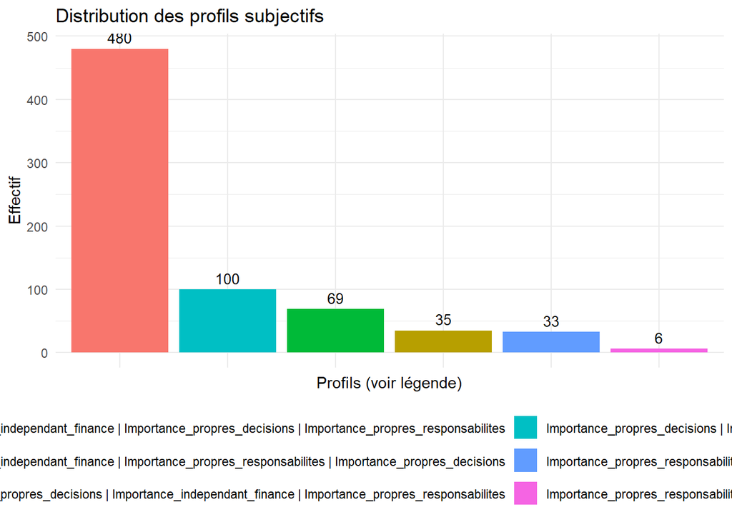

```r
library(ggplot2)
# Préparer les données
df_plot <- as.data.frame(table(data_P3_$Marqueurs_ordonnés_subj))
names(df_plot) <- c("Combinaison", "Effectif")

# Tri décroissant
df_plot <- df_plot[order(-df_plot$Effectif), ]

# Création d'un identifiant simplifié
df_plot$ID <- factor(1:nrow(df_plot))

# Graphique
ggplot(df_plot, aes(x = ID, y = Effectif, fill = Combinaison)) +
  geom_bar(stat = "identity") +
  geom_text(aes(label = Effectif), vjust = -0.5, size = 3.5) +
  labs(title = "Distribution des profils subjectifs",
       x = "Profils (voir légende)",
       y = "Effectif",
       fill = "Combinaison de valeurs perçues\ncomme importantes") +
  theme_minimal() +
  theme(axis.text.x = element_blank(),
        axis.ticks.x = element_blank(),
        legend.position = "bottom") +  # ✅ ici : "bottom" correct
  guides(fill = guide_legend(ncol = 2))  # ajuste à 2 colonnes si trop long
```

```r
library(TraMineR)
library(dplyr)
library(stringr)

# --- 1. Nettoyage, séparation des séquences et ajout de l'âge ---
data_seq <- data_P3_ %>%
  mutate(Marqueurs_split = str_split(Marqueurs_ordonnés_subj, " \\| ")) %>%
  mutate(
    M1 = sapply(Marqueurs_split, `[`, 1),
    M2 = sapply(Marqueurs_split, `[`, 2),
    M3 = sapply(Marqueurs_split, `[`, 3)
  ) %>%
  select(age, M1, M2, M3)  # Ajout de la variable age

# --- 2. Recodage lisible des états ---
etat_labels <- c(
  "Importance_independant_finance" = "finance",
  "Importance_propres_decisions" = "Décisions",
  "Importance_propres_responsabilites" = "Responsabilités"
)

# Recodage uniquement sur M1, M2, M3 (pas sur age)
data_seq <- data_seq %>%
  mutate(across(c(M1, M2, M3), ~ etat_labels[.]))

# --- 3. Création de l'objet séquentiel ---
# On retire la colonne 'age' pour créer l'objet séquentiel (car non séquentielle)
seq_obj <- seqdef(data_seq %>% select(M1, M2, M3))
```

### Clustering hiérarchique et Sauts d’inertie de la classification des séquences

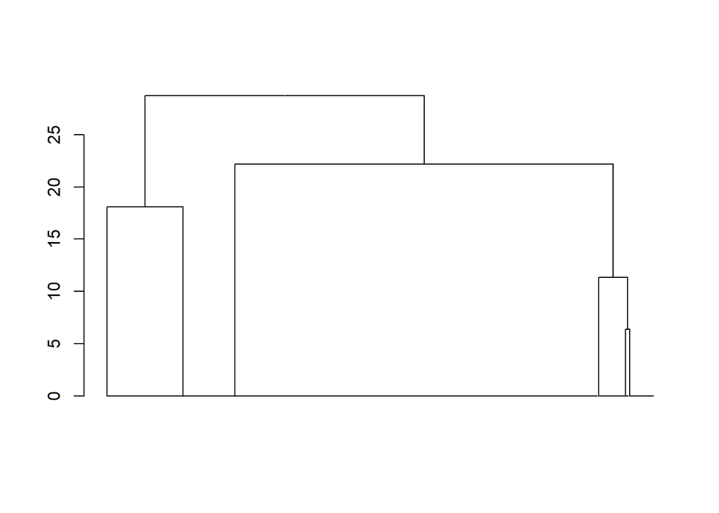

```r
library(TraMineR)
library(cluster)
library(dendextend)
# 1. Installer le bon package (une seule fois)
#install.packages("RColorBrewer")

# 2. Le charger
library(RColorBrewer)



# 1. Créer une matrice de coût constante
cost_matrix <- matrix(2, nrow = 3, ncol = 3)  # 3 états (adapter si besoin)
diag(cost_matrix) <- 0  # coût nul pour les substitutions identiques

# 2. Calcul de la distance avec OM (Optimal Matching)
seq.om <- seqdist(seq_obj, method = "OM",indel = 1, sm = cost_matrix)

#seq.om <- seqdist(seq_obj, method = "LCS")

# 3. Clustering hiérarchique
seq.dist <- hclust(as.dist(seq.om), method = "ward.D2")


plot(as.dendrogram(seq.dist), leaflab = "none")
```

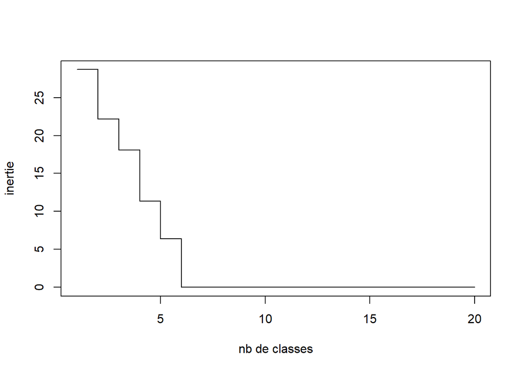

```r
#Sauts d’inertie de la classification des séquences
plot(sort(seq.dist$height, decreasing = TRUE)[1:20], type = "s", xlab = "nb de classes", ylab = "inertie")
```

### Affichage des sequences

```r
#choix d’une partition en 3 classes
nbcl <- 3
seq.part <- cutree(seq.dist, nbcl)

seq.part <- factor(seq.part, labels = paste("classe", 1:nbcl, sep = "."))
```

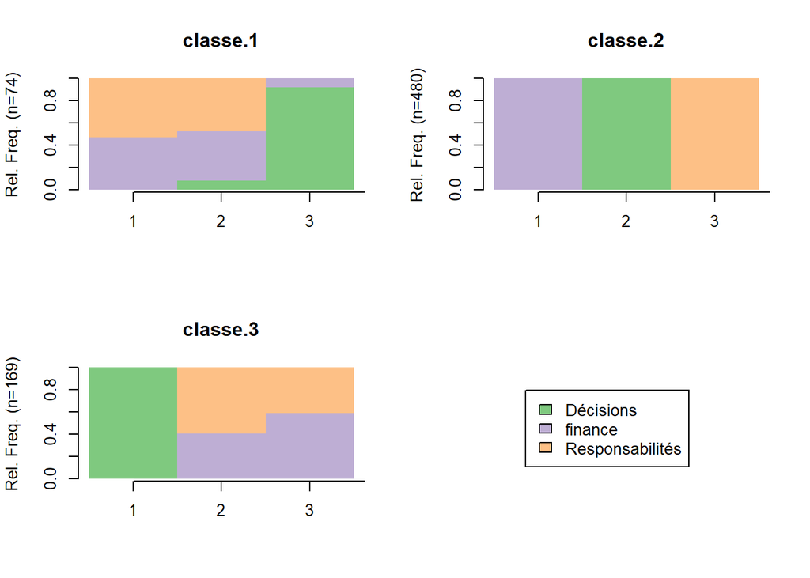

sequences

```r
seqdplot(seq_obj, group = seq.part, xtlab = 1:721, border = NA)
```

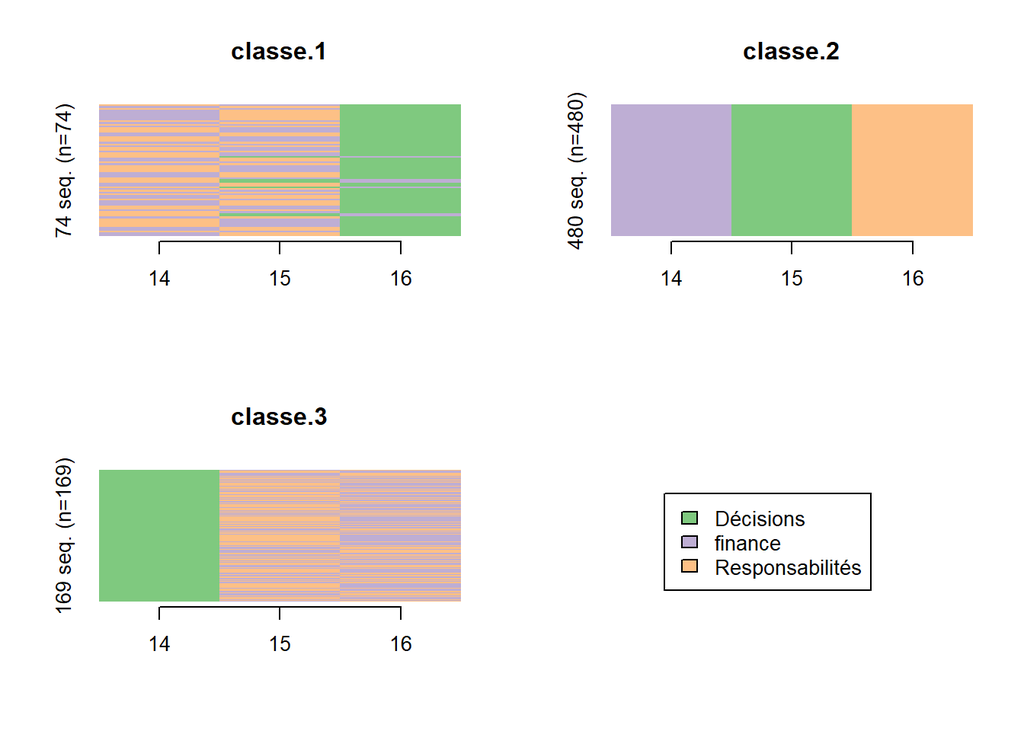

```r
seqIplot(seq_obj, group = seq.part, xtlab = 14:50, space = 0, border = NA, yaxis = FALSE)
```

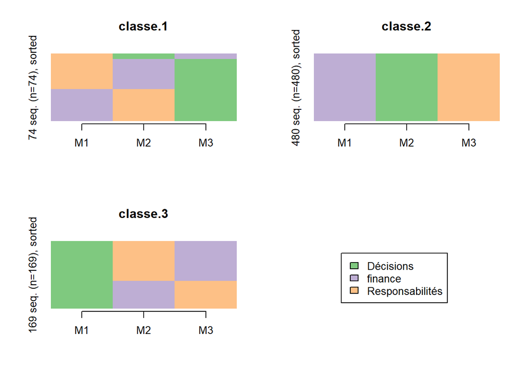

```r
ordre <- cmdscale(as.dist(seq.om), k = 1)
seqIplot(seq_obj, group = seq.part, sortv = ordre, space = 0, border = NA, yaxis = FALSE)
```

🔹 Classe 1 : Cette classe regroupe des individus qui accordent une forte importance aux responsabilités et à la finance dès les premières positions. Ensuite, ils continuent à valoriser, dans une moindre mesure, ces deux mêmes dimensions. Les décisions personnelles apparaissent plus rarement en deuxième position, et ne deviennent véritablement visibles qu’en dernière position. Cela reflète un profil où l’autonomie décisionnelle est reléguée au second plan, après les dimensions de gestion et d’engagement.

🔹 Classe 2 : Les individus de cette classe présentent un profil très structuré : ils placent en premier lieu l’indépendance financière, suivie de l’autonomie dans les décisions, puis de la prise de responsabilités. On observe ici une logique progressive où l’émancipation économique précède la capacité décisionnelle, elle-même précédant l’engagement en responsabilités.

🔹 Classe 3 : Cette classe est caractérisée par une priorité donnée aux décisions personnelles, en première position. Vient ensuite l’importance des responsabilités, suivie par une proportion modeste d’individus valorisant la finance. Contrairement à la classe 1, où la dimension décisionnelle est marginale, ici elle est au cœur des priorités. On y retrouve un profil presque inversé à celui de la classe 1, mettant l’accent sur l’autonomie et le pouvoir d’agir avant les aspects matériels et structurels.

## Analyse de séquences des variables objectifs

```r
# Définir les nouvelles colonnes subjectives
subj_vars_nouvelles <- c("Importance_quiter_nid",
                          "Importance_emploi_TPL",
                          "Importance_vivre_en_couple",
                          "Importance_marie_1er_fois",
                          "Importance_parent_1er_fois")

# Vérifier l'existence des colonnes dans data_P3_
if (!all(subj_vars_nouvelles %in% names(data_P3_))) {
  stop("Certaines colonnes subjectives ne sont pas présentes dans data_P3_.")
}

# S'assurer que les colonnes sont numériques
data_P3_[, subj_vars_nouvelles] <- lapply(data_P3_[, subj_vars_nouvelles], function(x) as.numeric(as.character(x)))

# Fonction pour trier les noms des variables selon les règles demandées
ordonner_par_valeur_et_nom <- function(x) {
  valeurs <- as.numeric(x)
  noms <- names(x)

  # Trier en ordre décroissant de valeur, puis alphabétique
  classement <- noms[order(-valeurs, noms)]

  paste(classement, collapse = " | ")  # tu peux changer le séparateur si tu veux
}

# Appliquer la fonction ligne par ligne
data_P3_$Marqueurs_ordonnés_obj <- apply(data_P3_[, subj_vars_nouvelles], 1, ordonner_par_valeur_et_nom)

# Aperçu des résultats
#View(data_P3_[, c(subj_vars_nouvelles, "Marqueurs_ordonnés_obj")])
```

```r
# Charger les packages nécessaires
library(dplyr)

# Vecteur des nouvelles variables subjectives
new_vars <- c("Importance_quiter_nid",
              "Importance_emploi_TPL",
              "Importance_vivre_en_couple",
              "Importance_marie_1er_fois",
              "Importance_parent_1er_fois")

# Générer toutes les permutations possibles
combinaisons_all <- gtools::permutations(n = length(new_vars), r = length(new_vars), v = new_vars)

# Coller les combinaisons sous forme de chaînes
combinaisons_chr <- apply(combinaisons_all, 1, function(x) paste(x, collapse = " | "))

# Créer une data frame avec ID
df_nouvelles_combinaisons <- data.frame(
  ID_combinaison = 1:length(combinaisons_chr),
  Combinaison = combinaisons_chr
)

# Afficher
#View(df_nouvelles_combinaisons)
```

```r
# Associer les ID de combinaison à chaque ligne de data_P3_
data_P3_$Marqueurs_obj <- sapply(data_P3_$Marqueurs_ordonnés_obj, function(x) {
  match_index <- match(x, df_nouvelles_combinaisons$Combinaison)
  if (!is.na(match_index)) {
    return(df_nouvelles_combinaisons$ID_combinaison[match_index])
  } else {
    return(NA)  # Si aucune correspondance trouvée
  }
})

# Vérification rapide des correspondances
#table(data_P3_$Marqueurs_obj, useNA = "ifany")

# Affichage des résultats
#View(data_P3_[, c("Marqueurs_ordonnés_obj", "Marqueurs_obj")])

#table(data_P3_$Marqueurs_obj, useNA = "ifany")
```

```r
# Sélectionner uniquement les colonnes souhaitées
df_verif <- data_P3_[, c("Marqueurs_ordonnés_obj", "Marqueurs_obj")]

# Afficher dans la console
#print(df_verif)

# Ou bien dans une fenêtre de visualisation
#View(df_verif)
```

```r
#Separation des sequences
library(stringr)
library(dplyr)

data_seq_obj <- data_P3_ %>%
  mutate(Marqueurs_split_obj = str_split(Marqueurs_ordonnés_obj, " \\| ")) %>%
  mutate(
    O1 = sapply(Marqueurs_split_obj, `[`, 1),
    O2 = sapply(Marqueurs_split_obj, `[`, 2),
    O3 = sapply(Marqueurs_split_obj, `[`, 3),
    O4 = sapply(Marqueurs_split_obj, `[`, 4),
    O5 = sapply(Marqueurs_split_obj, `[`, 5)
  ) %>%
  select(O1, O2, O3, O4, O5)
```

```r
#Recodage des états
# Recodage lisible des noms pour les graphiques
etat_labels_obj <- c(
  "Importance_quiter_nid" = "Quitter le nid",
  "Importance_emploi_TPL" = "Emploi stable",
  "Importance_vivre_en_couple" = "Vie de couple",
  "Importance_marie_1er_fois" = "Premier mariage",
  "Importance_parent_1er_fois" = "Premier enfant"
)

data_seq_obj <- data_seq_obj %>%
  mutate(across(everything(), ~ etat_labels_obj[.]))
```

```r
#Création de l'objet séquentiel
library(TraMineR)

seq_obj_obj <- seqdef(data_seq_obj)
```

### Calcul des distances & clustering

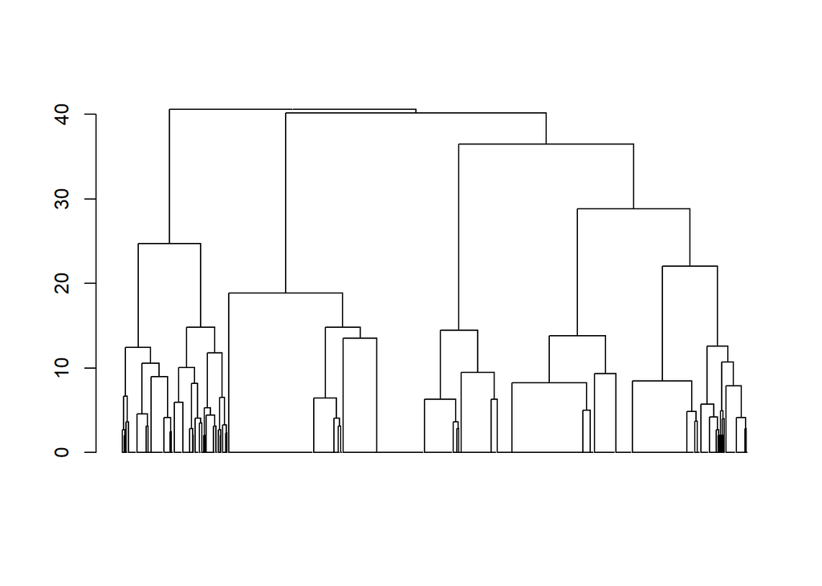

```r
# Matrice de coût (5 états ici)
cost_matrix_obj <- matrix(2, nrow = 5, ncol = 5)
diag(cost_matrix_obj) <- 0

# Distance OM
seq.om_obj <- seqdist(seq_obj_obj, method = "OM", indel = 1, sm = cost_matrix_obj)

# Clustering
seq.dist_obj <- hclust(as.dist(seq.om_obj), method = "ward.D2")

# Dendrogramme
plot(as.dendrogram(seq.dist_obj), leaflab = "none")
```

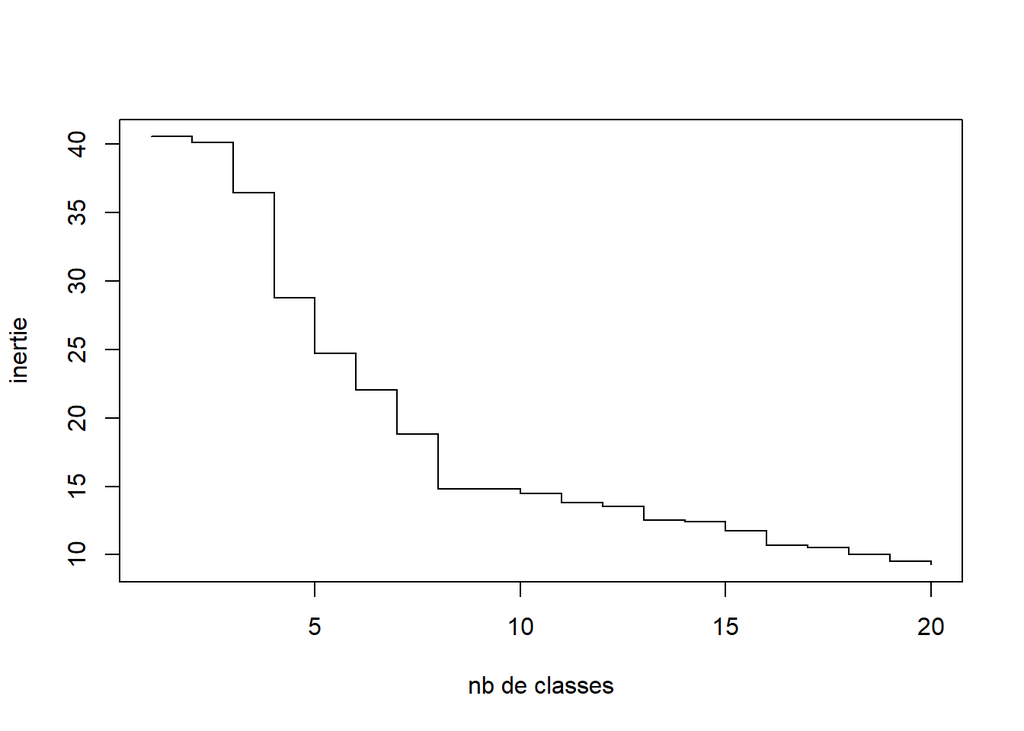

```r
# Choix du nombre de classes
plot(sort(seq.dist_obj$height, decreasing = TRUE)[1:20], type = "s", xlab = "nb de classes", ylab = "inertie")
```

```r
#Créer les classes
nbcl_obj <- 5
seq.part_obj <- cutree(seq.dist_obj, nbcl_obj)
seq.part_obj <- factor(seq.part_obj, labels = paste("classe", 1:nbcl_obj, sep = "."))
```

### Sequences

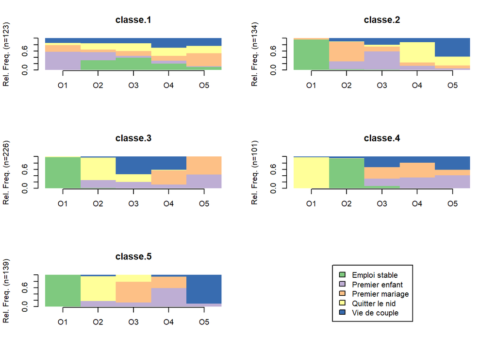

```r
# Distribution des états
seqdplot(seq_obj_obj, group = seq.part_obj, border = NA)
```

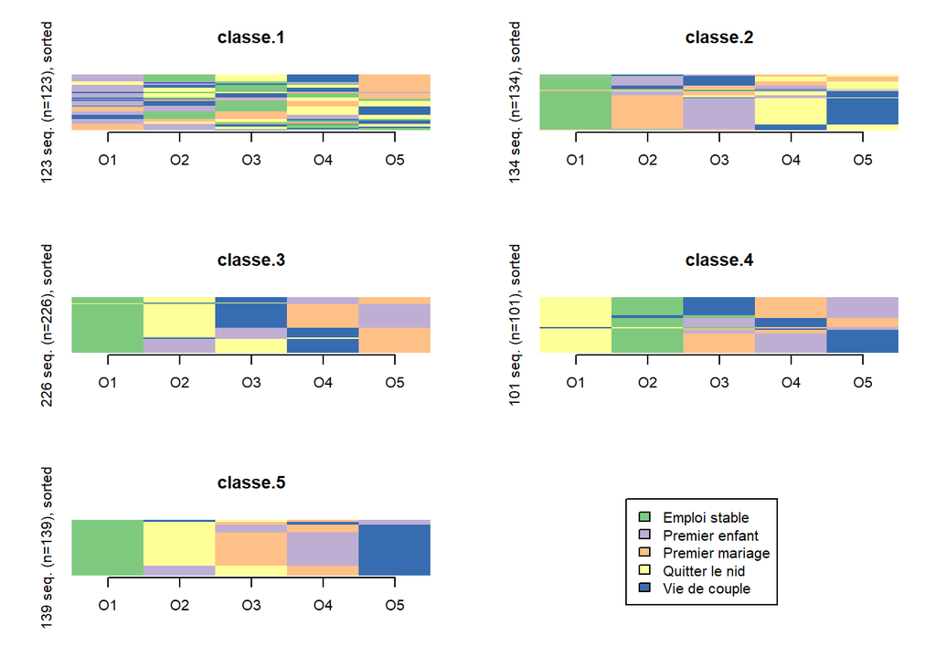

```r
# Index plot + tri
ordre_obj <- cmdscale(as.dist(seq.om_obj), k = 1)
seqIplot(seq_obj_obj, group = seq.part_obj, sortv = ordre_obj, space = 0, border = NA, yaxis = FALSE)
```

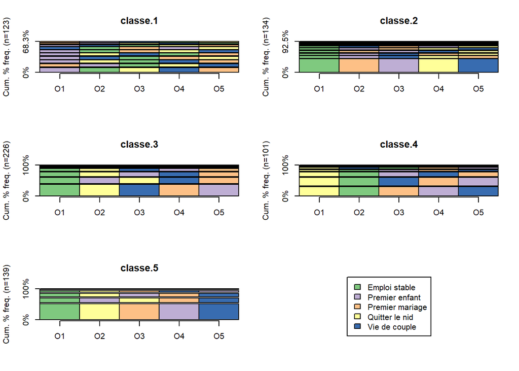

```r
# Fréquences
seqfplot(seq_obj_obj, group = seq.part_obj)
```

```r
# Heatmap
library(seqhandbook)
#seq_heatmap(seq_obj_obj, seq.om_obj)
```

[output not shown]

[output not shown]

```
Forte importance donnée d’emblée à l’emploi stable et quitter le nid.

Ensuite : montée en puissance des aspects affectifs.

Le mariage puis l’enfant prennent de l’importance en fin de parcours.

✅ Profil : vision très structurée, où l’emploi est vu comme préalable à tout.
```

🟠 Classe 4 (101 individus – profil inversé ou atypique)

[output not shown]

[output not shown]